# COVID Mortality Analysis Project

Author

Dane Pearson, Dhriti Avala

Published

November 9, 2026

# Statistical Analysis of US COVID-19 Mortality Rates in R:

## Install packages:

```r
library(lubridate)
library(ggplot2)
library(tidyr)
library(MASS)
library(DHARMa)
library(AER)
library(glmmTMB)
library(broom.mixed)
library(dplyr)
library(usmap)
library(broom)

# For formatting tables nicely
library(knitr)
```

## Load data:

```r
original_df <- read.csv(
  "data/COVID-19_Deaths_by_Sex_Age.csv",
  stringsAsFactors = TRUE
)

state_populations_data <- read.csv(
  "data/state_populations.csv",
  stringsAsFactors = TRUE
)

# Civilian population by state, single year of age, and sex (Census Vintage 2025).
# Lets each age-sex group's deaths be divided by THAT group's population.
age_sex_pops_df <- read.csv("data/age_sex_state_pops.csv")
```

## EDA:

### Make summary tables of both datasets:

```r
original_summary <- summary(original_df)
age_sex_pop_summary <- summary(age_sex_pops_df)

kable(
  original_summary,
  caption = "Original dataset summary",
  digits = 1,
  align = "l"
)
```

Original dataset summary

|  | Data.As.Of | Start.Date | End.Date | Group | Year | Month | State | Sex | Age.Group | COVID.19.Deaths | Total.Deaths | Pneumonia.Deaths | Pneumonia.and.COVID.19.Deaths | Influenza.Deaths | Pneumonia..Influenza..or.COVID.19.Deaths | Footnote |
| --- | --- | --- | --- | --- | --- | --- | --- | --- | --- | --- | --- | --- | --- | --- | --- | --- |
|  | 09/27/2023:137700 | 01/01/2020: 8262 | 09/23/2023: 8262 | By Month:123930 | Min. :2020 | Min. : 1.0 | Alabama : 2550 | All Sexes:45900 | 0-17 years : 8100 | 0 :50322 | : 19509 | :44864 | 0 :65019 | 0 :103435 | :44233 | :39804 |
|  | NA | 01/01/2021: 5508 | 12/31/2020: 5508 | By Total: 2754 | 1st Qu.:2020 | 1st Qu.: 3.0 | Alaska : 2550 | Female :45900 | 1-4 years : 8100 | :39430 | 0 : 2858 | 0 :36201 | :36884 | : 26688 | 0 :30828 | One or more data cells have counts between 1-9 and have been suppressed in accordance with NCHS confidentiality standards.:97896 |
|  | NA | 01/01/2022: 5508 | 12/31/2021: 5508 | By Year : 11016 | Median :2021 | Median : 6.0 | Arizona : 2550 | Male :45900 | 15-24 years: 8100 | 10 : 1491 | 10 : 1418 | 10 : 1665 | 10 : 1347 | 10 : 449 | 10 : 1660 | NA |
|  | NA | 01/01/2023: 5508 | 12/31/2022: 5508 | NA | Mean :2021 | Mean : 6.2 | Arkansas : 2550 | NA | 18-29 years: 8100 | 11 : 1332 | 11 : 1332 | 11 : 1431 | 11 : 1169 | 11 : 381 | 11 : 1478 | NA |
|  | NA | 02/01/2020: 2754 | 01/31/2020: 2754 | NA | 3rd Qu.:2022 | 3rd Qu.: 9.0 | California: 2550 | NA | 25-34 years: 8100 | 12 : 1166 | 13 : 1247 | 12 : 1337 | 12 : 1065 | 12 : 343 | 12 : 1434 | NA |
|  | NA | 02/01/2021: 2754 | 01/31/2021: 2754 | NA | Max. :2023 | Max. :12.0 | Colorado : 2550 | NA | 30-39 years: 8100 | 13 : 1097 | 12 : 1244 | 13 : 1274 | 13 : 968 | 13 : 318 | 13 : 1295 | NA |
|  | NA | (Other) :107406 | (Other) :107406 | NA | NA’s :2754 | NA’s :13770 | (Other) :122400 | NA | (Other) :89100 | (Other):42862 | (Other):110092 | (Other):50928 | (Other):31248 | (Other): 6086 | (Other):56772 | NA |

```r
kable(
  age_sex_pop_summary,
  caption = "Census age-sex population dataset summary",
  digits = 1,
  align = "l"
)
```

Census age-sex population dataset summary

|  | SUMLEV | REGION | DIVISION | STATE | NAME | SEX | AGE | ESTBASE2020_CIV | POPEST2020_CIV | POPEST2021_CIV | POPEST2022_CIV | POPEST2023_CIV | POPEST2024_CIV | POPEST2025_CIV |
| --- | --- | --- | --- | --- | --- | --- | --- | --- | --- | --- | --- | --- | --- | --- |
|  | Min. :10.00 | Min. :0.000 | Min. :0.000 | Min. : 0.00 | Length:13572 | Min. :0 | Min. : 0.00 | Min. : 585 | Min. : 587 | Min. : 617 | Min. : 632 | Min. : 658 | Min. : 706 | Min. : 768 |
|  | 1st Qu.:40.00 | 1st Qu.:2.000 | 1st Qu.:3.000 | 1st Qu.:15.75 | Class :character | 1st Qu.:0 | 1st Qu.: 21.00 | 1st Qu.: 12056 | 1st Qu.: 12072 | 1st Qu.: 12194 | 1st Qu.: 12332 | 1st Qu.: 12496 | 1st Qu.: 12683 | 1st Qu.: 12830 |
|  | Median :40.00 | Median :3.000 | Median :5.000 | Median :28.50 | Mode :character | Median :1 | Median : 43.00 | Median : 31291 | Median : 31346 | Median : 31522 | Median : 31778 | Median : 32147 | Median : 32550 | Median : 32792 |
|  | Mean :39.42 | Mean :2.615 | Mean :5.019 | Mean :28.40 | NA | Mean :1 | Mean : 53.49 | Mean : 194754 | Mean : 194791 | Mean : 195090 | Mean : 196233 | Mean : 197870 | Mean : 199790 | Mean : 200835 |
|  | 3rd Qu.:40.00 | 3rd Qu.:3.250 | 3rd Qu.:7.250 | 3rd Qu.:41.25 | NA | 3rd Qu.:2 | 3rd Qu.: 65.00 | 3rd Qu.: 66438 | 3rd Qu.: 66413 | 3rd Qu.: 66604 | 3rd Qu.: 66913 | 3rd Qu.: 67261 | 3rd Qu.: 67774 | 3rd Qu.: 68144 |
|  | Max. :40.00 | Max. :4.000 | Max. :9.000 | Max. :56.00 | NA | Max. :2 | Max. :999.00 | Max. :330399710 | Max. :330463429 | Max. :330970180 | Max. :332908812 | Max. :335687286 | Max. :338943547 | Max. :340716898 |

First convert Covid-19 Death column from factor to numeric, and remove commas in numbers:

```r
original_df$COVID.19.Deaths <- as.numeric(gsub(
  ",",
  "",
  original_df$COVID.19.Deaths
))

# The CDC age labels use en dashes ("15–24 years"), not hyphens ("15-24 years").
# Replace them so every filter in this file, written with plain hyphens, matches.
# "\u2013" is the code for an en dash.
original_df$Age.Group <- gsub(
  "\u2013",
  "-",
  as.character(original_df$Age.Group)
)
```

### Check for missing values:

```r
# Count num of missing values in the columns we care about
# (Some columns we will use have missing values intentionally based on schema)

col_nas <- colSums(is.na(original_df[, c(
  "Group",
  "State",
  "Sex",
  "Age.Group",
  "COVID.19.Deaths"
)]))

# Convert to a data frame with one row
col_nas_df <- as.data.frame(t(col_nas))

kable(
  col_nas_df,
  caption = "NAs per column",
  digits = 1,
  align = "c"
)
```

NAs per column

| Group | State | Sex | Age.Group | COVID.19.Deaths |
| --- | --- | --- | --- | --- |
| 0 | 0 | 0 | 0 | 39430 |

We did not impute at this stage, suppressed rows are excluded from the complete-case models, this missingness is not at random, and multiple imputation addresses it later.

### Verify no “Month” values fall outside 1-12:

```r
value_range <- range(original_df$Month, na.rm = TRUE)
print(paste(
  "Range of 'Month' column values:",
  value_range[1],
  "to",
  value_range[2]
))
```

```
[1] "Range of 'Month' column values: 1 to 12"
```

### Ensure no negative values for Covid-19 Deaths:

```r
min_value <- min(original_df$COVID.19.Deaths, na.rm = TRUE) # na.rm: ignore suppressed NAs
print(paste("Minimum value:", min_value))
```

```
[1] "Minimum value: 0"
```

### Plot total COVID-19 deaths over time in the U.S.

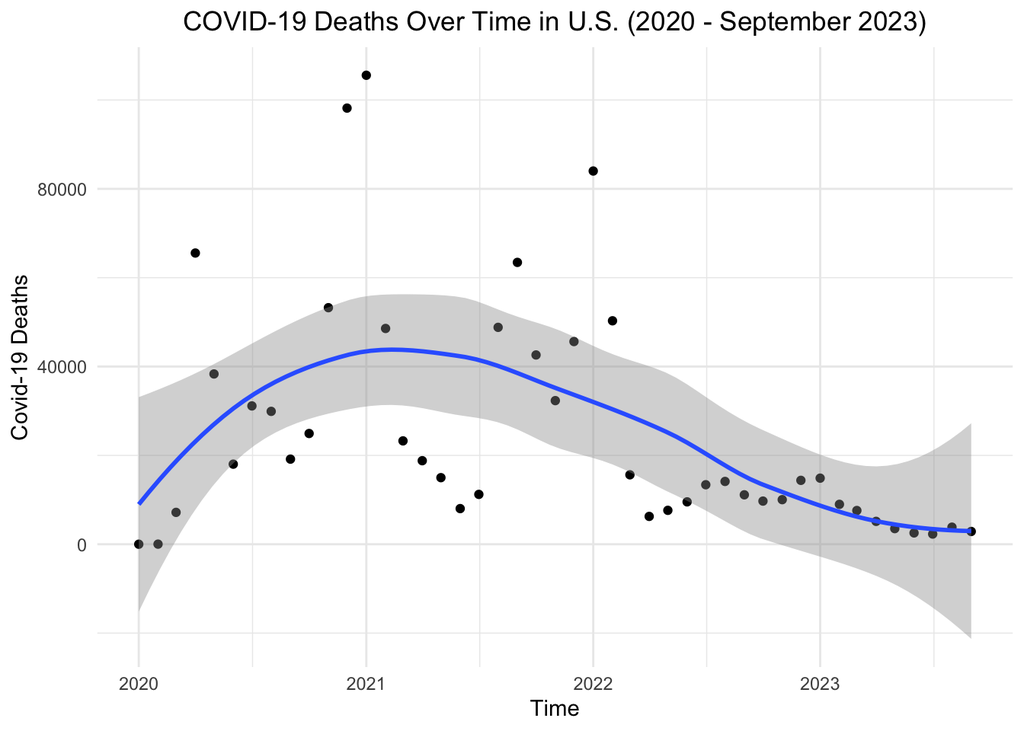

```r
deaths_per_month_df <- original_df %>%
  filter(
    Group == "By Month" &
      Sex == "All Sexes" &
      Age.Group == "All Ages" &
      State == "United States"
  ) |>
  dplyr::select(Year, Month, State, Sex, Age.Group, COVID.19.Deaths) %>%
  mutate(
    MonthDate = ymd(paste(Year, Month, "01", sep = "-"))
  )


ggplot(data = deaths_per_month_df, aes(x = MonthDate, y = COVID.19.Deaths)) +
  geom_point() +
  geom_smooth() +
  labs(
    title = "COVID-19 Deaths Over Time in U.S. (2020 - September 2023)",
    x = "Time",
    y = "Covid-19 Deaths"
  ) +
  theme_minimal() +
  theme(plot.title = element_text(hjust = 0.5))
```

Deaths from COVID-19 spiked drastically in late 2020 and early 2021, with the death count lowering in mid 2021 and leveling off by early 2023. By September of 2021, the US began administering booster shots. This could help to explain how the national death rate began declining at about the same time, since the vaccine has been an effective way to prevent covid-related hospitalizations and transmission of the virus.

### Did certain months have higher average deaths across all years?

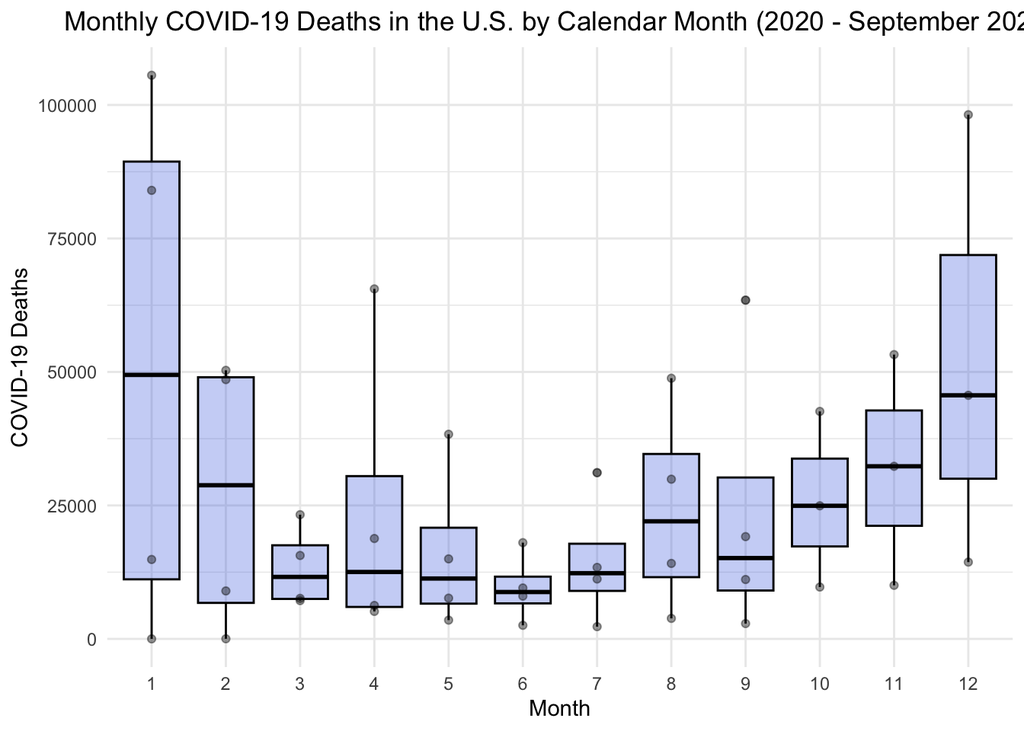

```r
# Boxplot for each month across all years in the dataset
ggplot(
  data = deaths_per_month_df,
  aes(x = factor(Month), y = COVID.19.Deaths)
) +
  geom_boxplot(color = "black", fill = "royalblue", alpha = 0.3) +
  geom_point(alpha = 0.4) +
  labs(
    title = "Monthly COVID-19 Deaths in the U.S. by Calendar Month (2020 - September 2023)",
    x = "Month",
    y = "COVID-19 Deaths"
  ) +
  theme_minimal() +
  theme(plot.title = element_text(hjust = 0.5))
```

Deaths peaked in December and January, consistent with winter surges in 2020–21 and 2022, though with only three to four years of data per month, this pattern cannot be separated from the timing of specific waves.

### How did deaths vary across age groups in the US?

```r
deaths_by_ages <- original_df %>%
  filter(
    Group == "By Total" &
      Sex == "All Sexes" &
      State == "United States" &
      Age.Group != "All Ages"
  ) |>
  dplyr::select(Age.Group, COVID.19.Deaths)

# emove the redundant and overlapping age groups
deaths_by_ages_clean <- deaths_by_ages %>%
  filter(
    !Age.Group %in%
      c(
        "0-17 years",
        "18-29 years",
        "30-39 years",
        "40-49 years",
        "50-64 years"
      )
  )

kable(
  deaths_by_ages_clean,
  caption = "Total COVID-19 Deaths per Age group",
  digits = 1,
  col.names = c("Age Group", "Total Deaths"),
  align = "l"
)
```

Total COVID-19 Deaths per Age group

| Age Group | Total Deaths |
| --- | --- |
| Under 1 year | 519 |
| 1-4 years | 285 |
| 5-14 years | 509 |
| 15-24 years | 3021 |
| 25-34 years | 12401 |
| 35-44 years | 30108 |
| 45-54 years | 71388 |
| 55-64 years | 159712 |
| 65-74 years | 256806 |
| 75-84 years | 300162 |
| 85 years and over | 311863 |

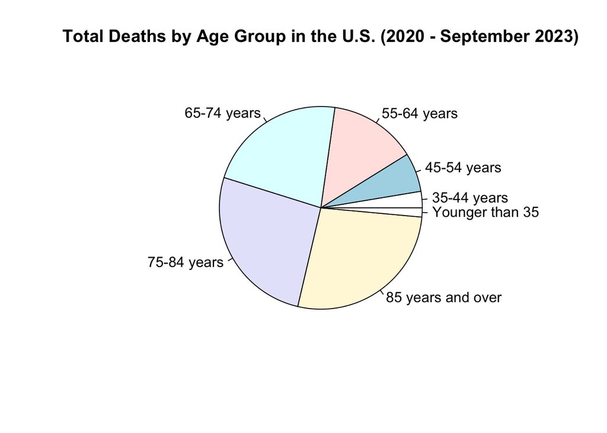

```r
# Add threshold to group together smaller slices
threshold <- 0.02 * sum(deaths_by_ages_clean$COVID.19.Deaths)

# Group the smaller slices
deaths_by_ages_clean$group <- ifelse(
  deaths_by_ages_clean$COVID.19.Deaths < threshold,
  "Younger than 35",
  as.character(deaths_by_ages_clean$Age.Group)
)

agg <- aggregate(COVID.19.Deaths ~ group, deaths_by_ages_clean, sum)

# Plot as pie chart
pie(
  agg$COVID.19.Deaths,
  labels = agg$group,
  main = "Total Deaths by Age Group in the U.S. (2020 - September 2023)"
)
```

### Data Preparation:

Before plotting the death rates spatially across US states, we need to get the populations of each state by doing a left join of US census data on the State column of the original dataset. Below are the first few rows of each of the datasets used in the join:

```r
# Right dataset
state_pops_clean <- state_populations_data |>
  dplyr::select(
    NAME,
    POPESTIMATE2020,
    POPESTIMATE2021,
    POPESTIMATE2022,
    POPESTIMATE2023
  ) %>%
  rename(State = NAME)

head_state_pops <- head(state_pops_clean, 3)

kable(
  head_state_pops,
  caption = "State Populations Dataset (right data)",
  digits = 1,
  col.names = c(
    "State",
    "2020 Population",
    "2021 Population",
    "2022 Population",
    "2023 Population"
  ),
  align = "l"
)
```

State Populations Dataset (right data)

| State | 2020 Population | 2021 Population | 2022 Population | 2023 Population |
| --- | --- | --- | --- | --- |
| United States | 331526933 | 332048977 | 333271411 | 334914895 |
| Northeast Region | 57430477 | 57243423 | 57026847 | 56983517 |
| New England | 15057898 | 15106108 | 15120739 | 15159777 |

```r
# Total state population, one row per state-year
state_pops_long <- state_pops_clean %>%
  pivot_longer(
    cols = starts_with("POPESTIMATE"),
    names_to = "Year",
    values_to = "Population"
  ) %>%
  mutate(Year = as.integer(gsub("POPESTIMATE", "", Year))) # "POPESTIMATE2020" -> 2020

# 11 age groups that do not overlap and together cover all ages.
# The CDC file also has overlapping groups (e.g., "0-17 years" overlaps
# "1-4 years" and "5-14 years"); keeping both would count deaths twice.
age_groups_keep <- c(
  "Under 1 year",
  "1-4 years",
  "5-14 years",
  "15-24 years",
  "25-34 years",
  "35-44 years",
  "45-54 years",
  "55-64 years",
  "65-74 years",
  "75-84 years",
  "85 years and over"
)

left_df <- original_df %>%
  filter(
    Group == "By Year", # one row per state-year-sex-age group
    Sex != "All Sexes", # keep Male and Female only
    Age.Group %in% age_groups_keep # drops "All Ages" and the overlapping groups
  ) %>%
  mutate(
    State = as.character(State), # factor -> text so joins match on names
    Sex = as.character(Sex),
    # CDC lists New York City separately from the rest of New York State,
    # but the Census "New York" population includes NYC, so combine them
    State = if_else(State == "New York City", "New York", State),
    # parse_date_time() (lubridate) reads either "2023-09-23" or "09/23/2023"
    start = as.Date(parse_date_time(
      as.character(Start.Date),
      orders = c("ymd", "mdy")
    )),
    end = as.Date(parse_date_time(
      as.character(End.Date),
      orders = c("ymd", "mdy")
    )),
    # Share of the year these counts cover: about 1 for 2020-2022,
    # about 0.73 for 2023 (data end in September 2023)
    year_fraction = (as.numeric(end - start) + 1) / 365.25
  ) %>%
  group_by(State, Year, Sex, Age.Group, year_fraction) %>%
  # sum() WITHOUT na.rm: if NYC or rest-of-NY is suppressed (NA), the combined
  # count is unknown, so it stays NA and is excluded later by drop_na()
  summarise(COVID.19.Deaths = sum(COVID.19.Deaths), .groups = "drop")


# Expect about 1.00 for 2020-2022, about 0.73 for 2023, and no NA
distinct(left_df, Year, year_fraction)
```

```
# A tibble: 4 × 2
   Year year_fraction
  <int>         <dbl>
1  2020         1.00
2  2021         0.999
3  2022         0.999
4  2023         0.728
```

```r
# Share of cells suppressed (NA) in each age group, states and DC only.
# Used to choose a reference age group that suppression barely affects.
suppression_by_age <- left_df %>%
  filter(!State %in% c("United States", "Puerto Rico")) %>% # match the rows used in the models
  mutate(Age.Group = factor(Age.Group, levels = age_groups_keep)) %>% # youngest to oldest
  group_by(Age.Group) %>%
  summarise(
    share_suppressed = mean(is.na(COVID.19.Deaths)), # mean of TRUE/FALSE = proportion TRUE
    .groups = "drop"
  )

kable(
  suppression_by_age,
  caption = "Share of Suppressed Cells by Age Group",
  digits = 2,
  col.names = c("Age Group", "Share Suppressed"),
  align = "l"
)
```

Share of Suppressed Cells by Age Group

| Age Group | Share Suppressed |
| --- | --- |
| Under 1 year | 0.49 |
| 1-4 years | 0.34 |
| 5-14 years | 0.48 |
| 15-24 years | 0.54 |
| 25-34 years | 0.38 |
| 35-44 years | 0.30 |
| 45-54 years | 0.15 |
| 55-64 years | 0.07 |
| 65-74 years | 0.03 |
| 75-84 years | 0.00 |
| 85 years and over | 0.00 |

```r
head_left <- head(left_df, 3)

kable(
  head_left,
  caption = "Processed CDC Death Counts (left data, first 3 rows)",
  digits = 1,
  col.names = c(
    "State",
    "Year",
    "Sex",
    "Age Group",
    "Year Fraction",
    "COVID-19 Deaths"
  ),
  align = "l"
)
```

Processed CDC Death Counts (left data, first 3 rows)

| State | Year | Sex | Age Group | Year Fraction | COVID-19 Deaths |
| --- | --- | --- | --- | --- | --- |
| Alabama | 2020 | Female | 1-4 years | 1 | 0 |
| Alabama | 2020 | Female | 15-24 years | 1 | NA |
| Alabama | 2020 | Female | 25-34 years | 1 | 17 |

```r
# Reshape the Census file to one row per state-year-sex-age group,
# binned into the same 11 age groups as the CDC data
age_sex_pops_long <- age_sex_pops_df %>%
  filter(
    as.numeric(SUMLEV) == 40, # state rows only ("040"; 010 = nation)
    SEX %in% c(1, 2), # 1 = Male, 2 = Female (0 = both combined)
    AGE != 999 # 999 = all ages combined
  ) %>%
  mutate(
    Sex = if_else(SEX == 1, "Male", "Female"),
    # cut() bins ages into intervals closed on the right:
    # (-Inf,0] = age 0, (0,4] = 1-4, (4,14] = 5-14, ..., (84,Inf] = 85+
    Age.Group = as.character(cut(
      AGE,
      breaks = c(-Inf, 0, 4, 14, 24, 34, 44, 54, 64, 74, 84, Inf),
      labels = age_groups_keep
    ))
  ) %>%
  dplyr::select(
    State = NAME,
    Sex,
    Age.Group,
    POPEST2020_CIV,
    POPEST2021_CIV,
    POPEST2022_CIV,
    POPEST2023_CIV
  ) %>%
  pivot_longer(
    cols = starts_with("POPEST"),
    names_to = "Year",
    values_to = "Population"
  ) %>%
  mutate(Year = as.integer(gsub("POPEST|_CIV", "", Year))) %>% # "POPEST2020_CIV" -> 2020
  group_by(State, Year, Sex, Age.Group) %>%
  summarise(Population = sum(Population), .groups = "drop") # add single ages within each bin

# Sanity check on the age binning: summed civilian age-sex populations should be
# just under each state's total resident population (civilians exclude active-duty military)
pop_check <- age_sex_pops_long %>%
  group_by(State, Year) %>%
  summarise(civilian = sum(Population), .groups = "drop") %>%
  inner_join(
    state_pops_long %>% mutate(State = as.character(State)),
    by = c("State", "Year")
  ) %>%
  mutate(ratio = civilian / Population)

summary(pop_check$ratio) # expect values just under 1
```

```
   Min. 1st Qu.  Median    Mean 3rd Qu.    Max.
 0.9692  0.9959  0.9982  0.9972  1.0001  1.0114
```

```r
pop_check %>% arrange(ratio) %>% head(5) # lowest ratios: likely states with large military populations
```

```
# A tibble: 5 × 5
  State   Year civilian Population ratio
  <chr>  <int>    <int>      <int> <dbl>
1 Alaska  2021   712293     734923 0.969
2 Hawaii  2022  1396594    1439399 0.970
3 Alaska  2022   711502     733276 0.970
4 Hawaii  2021  1404106    1446745 0.971
5 Alaska  2020   711560     732964 0.971
```

```r
# Join the two datasets using a left join
# Each row's Population is now that age-sex group's population in that state-year
joined_df <- left_df %>%
  left_join(age_sex_pops_long, by = c("State", "Year", "Sex", "Age.Group")) %>%
  mutate(
    # Person-years at risk: population scaled by the share of the year covered,
    # so partial-year 2023 is not compared against a full year of population
    person_years = Population * year_fraction,
    deaths_per_100000 = (COVID.19.Deaths / person_years) * 100000, # per 100,000 person-years
    State = tolower(State) # lowercase names for the map
  )

# Check: only non-states (e.g., "united states", "puerto rico") should be listed
joined_df %>% filter(is.na(Population)) %>% distinct(State)
```

```
# A tibble: 2 × 1
  State
  <chr>
1 puerto rico
2 united states
```

```r
head_joined <- head(joined_df, 3)

kable(
  head_joined,
  caption = "Left Join of Mortality and Populations Datasets",
  digits = 1,
  col.names = c(
    "State",
    "Year",
    "Sex",
    "Age Group",
    "Year Fraction",
    "COVID-19 Deaths",
    "Population",
    "Person-Years",
    "Deaths per 100,000 Person-Years"
  ),
  align = "l"
)
```

Left Join of Mortality and Populations Datasets

| State | Year | Sex | Age Group | Year Fraction | COVID-19 Deaths | Population | Person-Years | Deaths per 100,000 Person-Years |
| --- | --- | --- | --- | --- | --- | --- | --- | --- |
| alabama | 2020 | Female | 1-4 years | 1 | 0 | 114841 | 115076.8 | 0.0 |
| alabama | 2020 | Female | 15-24 years | 1 | NA | 347569 | 348282.7 | NA |
| alabama | 2020 | Female | 25-34 years | 1 | 17 | 320104 | 320761.3 | 5.3 |

##### Add a region column and remove territories and suppressed cells.

```r
# Define the states in each region:
west <- c(
  "alaska",
  "hawaii",
  "washington",
  "oregon",
  "california",
  "nevada",
  "idaho",
  "montana",
  "wyoming",
  "utah",
  "colorado",
  "arizona",
  "new mexico"
)

midwest <- c(
  "north dakota",
  "south dakota",
  "nebraska",
  "kansas",
  "minnesota",
  "iowa",
  "missouri",
  "wisconsin",
  "illinois",
  "indiana",
  "michigan",
  "ohio"
)

south <- c(
  "delaware",
  "maryland",
  "virginia",
  "west virginia",
  "kentucky",
  "tennessee",
  "north carolina",
  "south carolina",
  "georgia",
  "florida",
  "alabama",
  "mississippi",
  "arkansas",
  "louisiana",
  "texas",
  "oklahoma",
  "district of columbia"
)

northeast <- c(
  "maine",
  "new hampshire",
  "vermont",
  "massachusetts",
  "rhode island",
  "connecticut",
  "new york",
  "new jersey",
  "pennsylvania"
)

# Add region column, drop territories (region = NA) and CDC-suppressed counts
# (COVID.19.Deaths = NA), and sort by year ascending
joined_regional_df <- joined_df %>%
  mutate(
    region = case_when(
      State %in% west ~ "west",
      State %in% midwest ~ "midwest",
      State %in% south ~ "south",
      State %in% northeast ~ "northeast",
      TRUE ~ NA_character_
    )
  ) %>%
  mutate(region = as.factor(region)) %>%
  drop_na() %>%
  arrange(Year)

kable(
  head(joined_regional_df),
  caption = "Joined Dataset with Region and Death Rate Columns",
  digits = 1,
  col.names = c(
    "State",
    "Year",
    "Sex",
    "Age Group",
    "Year Fraction",
    "COVID-19 Deaths",
    "Group Population",
    "Person-Years",
    "Deaths per 100,000 Person-Years",
    "Region"
  ),
  align = "l"
)
```

Joined Dataset with Region and Death Rate Columns

| State | Year | Sex | Age Group | Year Fraction | COVID-19 Deaths | Group Population | Person-Years | Deaths per 100,000 Person-Years | Region |
| --- | --- | --- | --- | --- | --- | --- | --- | --- | --- |
| alabama | 2020 | Female | 1-4 years | 1 | 0 | 114841 | 115076.8 | 0.0 | south |
| alabama | 2020 | Female | 25-34 years | 1 | 17 | 320104 | 320761.3 | 5.3 | south |
| alabama | 2020 | Female | 35-44 years | 1 | 54 | 313868 | 314512.5 | 17.2 | south |
| alabama | 2020 | Female | 45-54 years | 1 | 168 | 319750 | 320406.6 | 52.4 | south |
| alabama | 2020 | Female | 5-14 years | 1 | 0 | 306584 | 307213.5 | 0.0 | south |
| alabama | 2020 | Female | 55-64 years | 1 | 369 | 353563 | 354289.0 | 104.2 | south |

### Choropleth Heatmap Plots:

##### Finally, plot the choropleth maps for 2020 - September 2023:

```r
# One row per state-year (all ages, both sexes) so each state gets one color.
map_df <- original_df %>%
  filter(Group == "By Year", Sex == "All Sexes", Age.Group == "All Ages") %>%
  mutate(
    State = as.character(State),
    State = if_else(State == "New York City", "New York", State),
    start = as.Date(parse_date_time(
      as.character(Start.Date),
      orders = c("ymd", "mdy")
    )),
    end = as.Date(parse_date_time(
      as.character(End.Date),
      orders = c("ymd", "mdy")
    )),
    year_fraction = (as.numeric(end - start) + 1) / 365.25
  ) %>%
  group_by(State, Year, year_fraction) %>%
  summarise(COVID.19.Deaths = sum(COVID.19.Deaths), .groups = "drop") %>%
  left_join(
    state_pops_long %>% mutate(State = as.character(State)), # total state population
    by = c("State", "Year")
  ) %>%
  mutate(
    deaths_per_100000 = COVID.19.Deaths / (Population * year_fraction) * 100000,
    State = tolower(State)
  )

# Same color scale limits for all four maps, so a given color means the same
# rate in every year (separate plots would otherwise each get their own scale)
rate_limits <- range(
  map_df$deaths_per_100000[
    !map_df$State %in% c("united states", "puerto rico")
  ],
  na.rm = TRUE
)

# Draws one labeled state map for a given year
plot_rate_map <- function(year) {
  year_df <- map_df %>%
    filter(Year == year, !State %in% c("united states", "puerto rico")) %>%
    mutate(state = tools::toTitleCase(State)) %>% # usmap needs a column named "state" (full name or abbreviation)
    dplyr::select(state, deaths_per_100000)

  plot_usmap(
    data = year_df,
    values = "deaths_per_100000", # column used for the fill color
    labels = TRUE, # state abbreviations
    label_color = "white"
  ) +
    scale_fill_viridis_c(
      option = "viridis",
      limits = rate_limits, # shared scale across years
      end = 0.85, # skip the brightest yellow so white labels stay readable
      name = "Deaths per\n100,000 Person-Years"
    ) +
    labs(title = paste("COVID-19 Mortality Rates by State,", year)) +
    theme(
      legend.position = "right",
      plot.title = element_text(
        size = 16, # title font size in points (the default is about 13)
        hjust = 0.5 # center the title
      )
    )
}

# Builds a top-10 table of state death rates for one year
top10_by_year <- function(year) {
  kable(
    map_df %>%
      filter(
        Year == year, # only the requested year
        !State %in% c("united states", "puerto rico") # drop non-state rows
      ) %>%
      arrange(desc(deaths_per_100000)) %>% # highest rate first
      head(10) %>% # top 10 states
      mutate(State = tools::toTitleCase(State)) %>% # restore capitalization
      dplyr::select(State, deaths_per_100000, COVID.19.Deaths, Population),
    caption = paste("Top 10 States by COVID-19 Mortality Rate,", year), # e.g., "..., 2021"
    digits = 1,
    format.args = list(big.mark = ","),
    col.names = c(
      "State",
      "Deaths per 100,000 Person-Years",
      "COVID-19 Deaths",
      "Population"
    ),
    align = "l"
  )
}
```

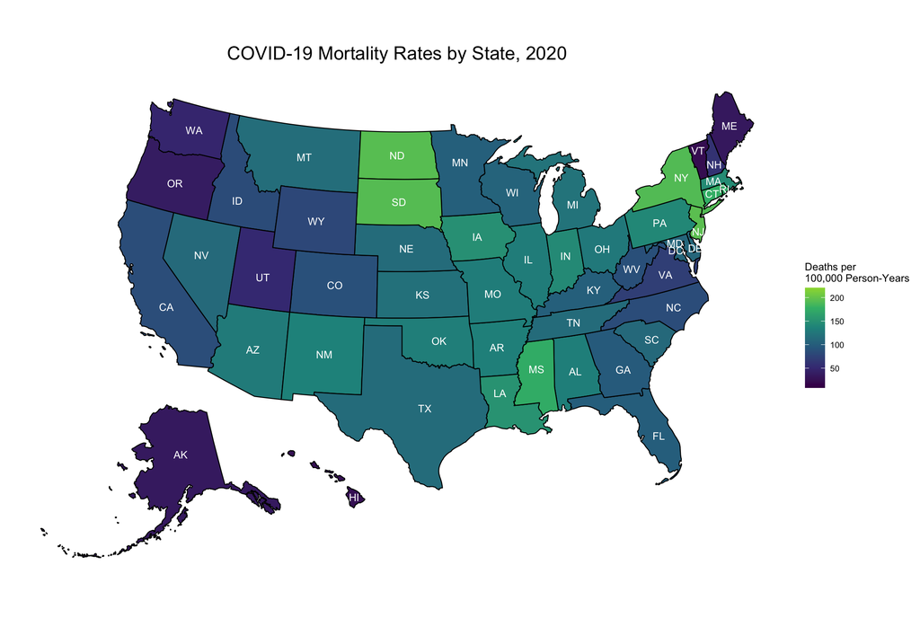

```r
plot_rate_map(2020)
```

```r
top10_by_year(2020)
```

Top 10 States by COVID-19 Mortality Rate, 2020

| State | Deaths per 100,000 Person-Years | COVID-19 Deaths | Population |
| --- | --- | --- | --- |
| New Jersey | 195.5 | 18,164 | 9,272,392 |
| North Dakota | 193.7 | 1,513 | 779,563 |
| South Dakota | 192.8 | 1,715 | 887,852 |
| New York | 191.0 | 38,477 | 20,104,710 |
| Connecticut | 175.7 | 6,298 | 3,577,586 |
| Rhode Island | 174.6 | 1,918 | 1,096,444 |
| Mississippi | 174.1 | 5,162 | 2,958,409 |
| Louisiana | 151.6 | 7,066 | 4,652,022 |
| District of Columbia | 149.4 | 1,004 | 670,839 |
| Iowa | 149.1 | 4,769 | 3,190,904 |

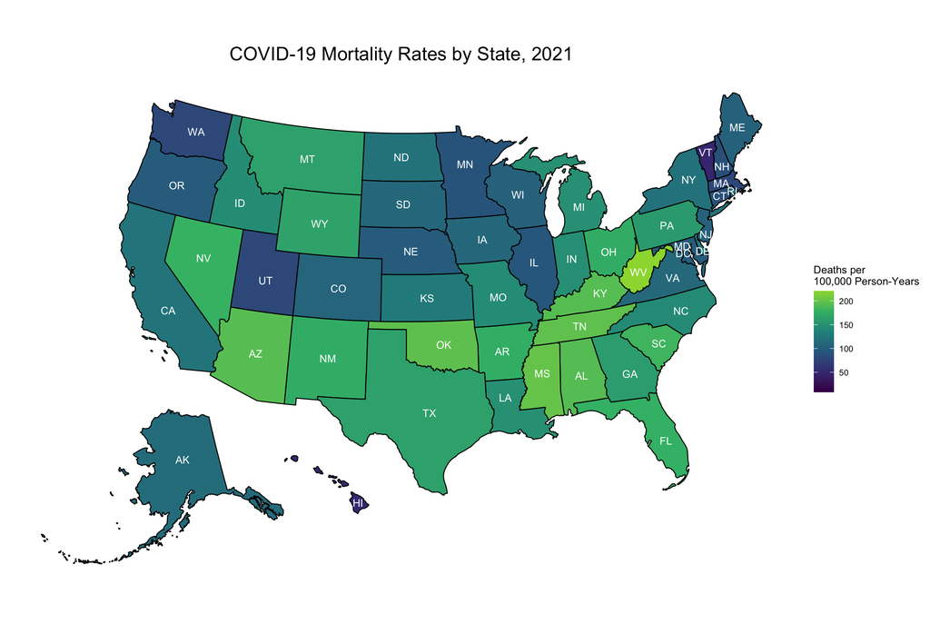

```r
plot_rate_map(2021)
```

```r
top10_by_year(2021)
```

Top 10 States by COVID-19 Mortality Rate, 2021

| State | Deaths per 100,000 Person-Years | COVID-19 Deaths | Population |
| --- | --- | --- | --- |
| West Virginia | 220.7 | 3,938 | 1,785,249 |
| Mississippi | 200.4 | 5,907 | 2,949,582 |
| Tennessee | 196.9 | 13,705 | 6,963,709 |
| Oklahoma | 196.8 | 7,850 | 3,991,634 |
| Arizona | 193.5 | 14,060 | 7,272,487 |
| Kentucky | 193.0 | 8,695 | 4,507,600 |
| Alabama | 192.6 | 9,719 | 5,050,380 |
| South Carolina | 183.0 | 9,497 | 5,193,848 |
| Nevada | 179.5 | 5,645 | 3,146,632 |
| Florida | 178.2 | 38,873 | 21,830,708 |

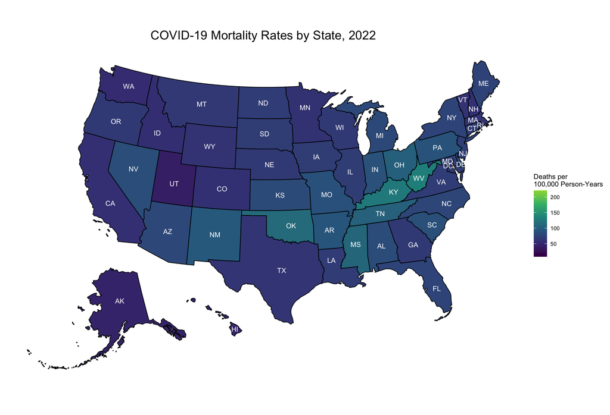

```r
plot_rate_map(2022)
```

```r
top10_by_year(2022)
```

Top 10 States by COVID-19 Mortality Rate, 2022

| State | Deaths per 100,000 Person-Years | COVID-19 Deaths | Population |
| --- | --- | --- | --- |
| West Virginia | 133.1 | 2,360 | 1,774,035 |
| Kentucky | 127.7 | 5,756 | 4,511,563 |
| Oklahoma | 113.6 | 4,562 | 4,019,271 |
| Mississippi | 108.6 | 3,190 | 2,938,928 |
| Tennessee | 102.5 | 7,223 | 7,048,976 |
| Ohio | 101.9 | 11,972 | 11,759,697 |
| New Mexico | 95.1 | 2,008 | 2,113,476 |
| Arkansas | 91.1 | 2,773 | 3,046,404 |
| Pennsylvania | 89.8 | 11,642 | 12,972,091 |
| Indiana | 88.3 | 6,032 | 6,832,274 |

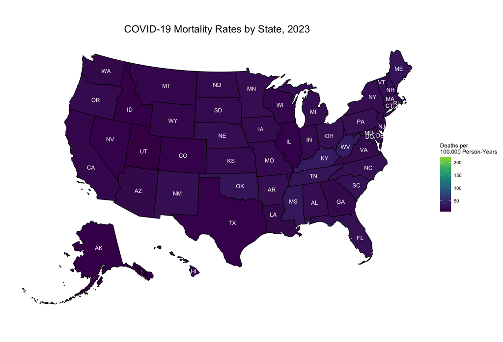

```r
# 2023 map covers January to September, annualized
plot_rate_map(2023)
```

```r
top10_by_year(2023)
```

Top 10 States by COVID-19 Mortality Rate, 2023

| State | Deaths per 100,000 Person-Years | COVID-19 Deaths | Population |
| --- | --- | --- | --- |
| West Virginia | 37.0 | 477 | 1,770,071 |
| Kentucky | 36.5 | 1,204 | 4,526,154 |
| Mississippi | 32.5 | 696 | 2,939,690 |
| Tennessee | 29.9 | 1,553 | 7,126,489 |
| Oklahoma | 29.1 | 860 | 4,053,824 |
| Delaware | 28.7 | 216 | 1,031,890 |
| Maine | 28.4 | 289 | 1,395,722 |
| Vermont | 27.8 | 131 | 647,464 |
| South Carolina | 27.3 | 1,068 | 5,373,555 |
| Florida | 26.1 | 4,296 | 22,610,726 |

#### Interpretation:

- **2020:** The highest crude mortality rates were in the Northeast (New Jersey, 195.5 per 100,000; New York, 191.0) and the Northern Plains (North Dakota, 193.7; South Dakota, 192.8), reflecting the early spring wave in the Northeast and the late-2020 surge in the Plains.
- **2021:** High mortality rates shifted to the South, Appalachia, and the Southwest. West Virginia had the highest rate of any state in any year (220.7), followed by Mississippi, Tennessee, Oklahoma, and Arizona, while most Northeastern states were among the lowest.
- **2022–2023:** Rates fell in every state, but the same Appalachian and South-Central states (West Virginia, Kentucky, Oklahoma, Mississippi, Tennessee) remained at the top. The 2023 rates cover January–September and are annualized.
- **Crude vs. age-adjusted:** These maps show crude rates, which are not adjusted for age. States with older populations rank higher partly because of their age structure. For example, Florida and Vermont appear among the top 10 crude rates in some years, yet the mixed model, which adjusts for age, sex, and year, estimates both below their predicted rates (Vermont among the lowest of all states). The age-adjusted state effects in the caterpillar plot are therefore the better comparison of state-level risk.

## Statistical Analysis:

*How are age, sex, region, and year associated with COVID-19 mortality rates?*

### Multiple Linear Regression:

```r
model_df <- joined_regional_df %>%
  mutate(
    # Youngest to oldest, so tables and plots read in order
    Age.Group = factor(Age.Group, levels = age_groups_keep),
    # Reference group that all other age groups are compared to
    Age.Group = relevel(Age.Group, ref = "65-74 years"), # 3% suppressed; large, stable baseline
    Sex = factor(Sex, levels = c("Female", "Male")) # Female = baseline, as before
  )

mlr_model <- lm(
  deaths_per_100000 ~ factor(Year) + Age.Group + region + Sex,
  data = model_df
)

summary(mlr_model)
```

```
Call:
lm(formula = deaths_per_100000 ~ factor(Year) + Age.Group + region +
    Sex, data = model_df)

Residuals:
    Min      1Q  Median      3Q     Max
-1114.6  -101.2   -20.0    90.8  3675.3

Coefficients:
                           Estimate Std. Error t value Pr(>|t|)
(Intercept)                 271.659     18.166  14.954  < 2e-16 ***
factor(Year)2021            -25.698     12.638  -2.033   0.0421 *
factor(Year)2022           -138.933     13.041 -10.653  < 2e-16 ***
factor(Year)2023           -299.724     13.170 -22.759  < 2e-16 ***
Age.GroupUnder 1 year      -171.686     22.806  -7.528 6.58e-14 ***
Age.Group1-4 years         -181.878     21.095  -8.622  < 2e-16 ***
Age.Group5-14 years        -173.134     22.704  -7.626 3.14e-14 ***
Age.Group15-24 years       -168.670     23.622  -7.140 1.14e-12 ***
Age.Group25-34 years       -210.225     21.524  -9.767  < 2e-16 ***
Age.Group35-44 years       -203.603     20.718  -9.827  < 2e-16 ***
Age.Group45-54 years       -158.783     19.598  -8.102 7.52e-16 ***
Age.Group55-64 years       -101.006     19.140  -5.277 1.40e-07 ***
Age.Group75-84 years        268.277     18.810  14.262  < 2e-16 ***
Age.Group85 years and over 1114.997     18.799  59.311  < 2e-16 ***
regionnortheast             -27.157     14.542  -1.867   0.0619 .
regionsouth                   8.431     12.419   0.679   0.4973
regionwest                  -56.325     13.126  -4.291 1.83e-05 ***
SexMale                      92.528      9.204  10.053  < 2e-16 ***
---
Signif. codes:  0 '***' 0.001 '**' 0.01 '*' 0.05 '.' 0.1 ' ' 1

Residual standard error: 266.3 on 3334 degrees of freedom
Multiple R-squared:  0.7269,    Adjusted R-squared:  0.7255
F-statistic:   522 on 17 and 3334 DF,  p-value: < 2.2e-16
```

**Model notes:**

- The reference group (intercept) is 2020, Midwest, female, and ages 65–74.
- Year is treated as a factor because mortality did not change linearly over time: it peaked in 2021 and then declined. A factor fits a separate mean for each year.

#### **Interpretation:**

- The model explains about 73% of the variation in mortality rates (adjusted R² = 0.726).
- Coefficients are additive differences in deaths per 100,000 person-years, holding the other variables fixed. For example, adults 85 and older had 1115 more deaths per 100,000 person-years than adults aged 65–74, and the South had 8.4 more than the Midwest.
- An additive model is poorly suited to these data. Age multiplies mortality risk rather than adding a fixed amount, so the same difference cannot apply across groups whose rates differ by orders of magnitude. The diagnostics below confirm the model’s assumptions are violated, which motivates the count models that follow.

#### **Diagnostic plots for regression:**

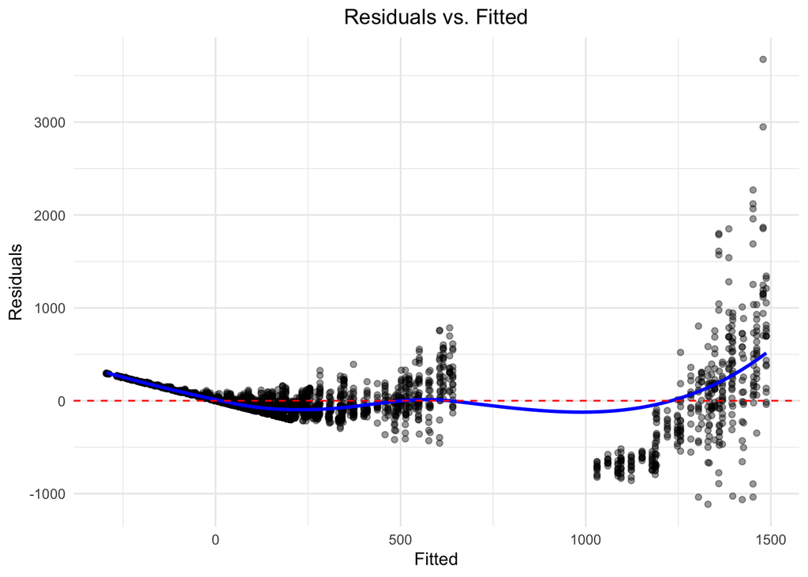

```r
# Residuals vs Fitted
# Check linearity and homoscedasticity
ggplot(augment(mlr_model), aes(.fitted, .resid)) + # add fitted values and residuals as columns
  geom_point(alpha = 0.4) +
  geom_smooth(method = "loess", se = FALSE, color = "blue") +
  geom_hline(yintercept = 0, linetype = "dashed", color = "red") +
  labs(title = "Residuals vs. Fitted", x = "Fitted", y = "Residuals") +
  theme_minimal() +
  theme(plot.title = element_text(hjust = 0.5))
```

The Residuals vs Fitted plot demonstrates that the model clearly violates the assumption of **linearity**. By looking at the plot, we can see that the predictors (year, region, age, and sex) and the response variable (death rate) are not linearly related. The wavy LOESS curve demonstrates an uneven spread around the residuals = 0 line, indicating that the model is potentially overpredicting in some ranges and underpredicting in others. The assumption of **constant variance** (homoscedasticity) is also violated, exhibited by the widening funnel shape in the plot. The residuals at lower fitted values are closer together, while those at higher fitted values spread out more dramatically. This means that the variance in error grows as the predicted mortality increases.

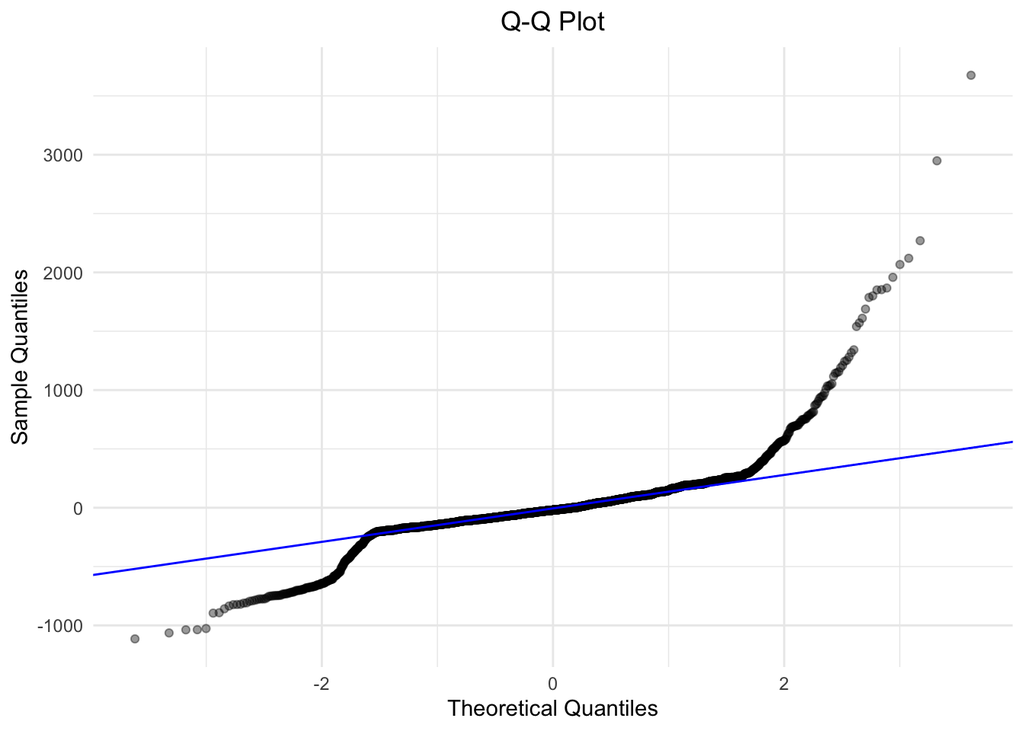

```r
# Q-Q Plot
# Check normality of residuals
ggplot(augment(mlr_model), aes(sample = .resid)) +
  stat_qq(alpha = 0.4) +
  stat_qq_line(color = "blue") +
  labs(
    title = "Q-Q Plot",
    x = "Theoretical Quantiles",
    y = "Sample Quantiles"
  ) +
  theme_minimal() +
  theme(plot.title = element_text(hjust = 0.5))
```

### Poisson Regression:

Use Poisson regression to more accurately model the COVID deaths, since our data is count data not continuous.

```r
poisson_regression <- glm(
  COVID.19.Deaths ~ Sex + region + factor(Year) + Age.Group, # Year as factor, as in the MLR
  family = poisson,
  offset = log(person_years), # group-specific person-years at risk
  data = model_df
)

summary(poisson_regression)
```

```
Call:
glm(formula = COVID.19.Deaths ~ Sex + region + factor(Year) +
    Age.Group, family = poisson, data = model_df, offset = log(person_years))

Coefficients:
                            Estimate Std. Error   z value Pr(>|z|)
(Intercept)                -6.212059   0.003178 -1954.774   <2e-16 ***
SexMale                     0.453870   0.001889   240.232   <2e-16 ***
regionnortheast             0.027882   0.002972     9.381   <2e-16 ***
regionsouth                 0.098074   0.002508    39.101   <2e-16 ***
regionwest                 -0.148278   0.002948   -50.292   <2e-16 ***
factor(Year)2021            0.168406   0.002182    77.184   <2e-16 ***
factor(Year)2022           -0.487052   0.002585  -188.444   <2e-16 ***
factor(Year)2023           -1.736030   0.004734  -366.711   <2e-16 ***
Age.GroupUnder 1 year      -5.251972   0.144351   -36.383   <2e-16 ***
Age.Group1-4 years         -7.709779   0.204119   -37.771   <2e-16 ***
Age.Group5-14 years        -7.387841   0.124051   -59.555   <2e-16 ***
Age.Group15-24 years       -4.534022   0.021629  -209.624   <2e-16 ***
Age.Group25-34 years       -3.251319   0.009422  -345.061   <2e-16 ***
Age.Group35-44 years       -2.345189   0.006149  -381.405   <2e-16 ***
Age.Group45-54 years       -1.447824   0.004238  -341.611   <2e-16 ***
Age.Group55-64 years       -0.708928   0.003188  -222.370   <2e-16 ***
Age.Group75-84 years        0.861822   0.002689   320.505   <2e-16 ***
Age.Group85 years and over  1.920870   0.002673   718.538   <2e-16 ***
---
Signif. codes:  0 '***' 0.001 '**' 0.01 '*' 0.05 '.' 0.1 ' ' 1

(Dispersion parameter for poisson family taken to be 1)

    Null deviance: 2719122  on 3351  degrees of freedom
Residual deviance:  135113  on 3334  degrees of freedom
AIC: 152342

Number of Fisher Scoring iterations: 6
```

#### **Interpretation:**

The Poisson model serves as the baseline count model. Before interpreting the results, it is important to note that the residual deviance (135,113) is much larger than the degrees of freedom (3,334), signaling overdispersion.

### Checking for Overdispersion:

##### Does the Poisson assumption (variance = mean) hold?

```r
# Pearson residuals: (observed - fitted) / sqrt(fitted), i.e., scaled by the Poisson SD
pearson_chi2 <- sum(residuals(poisson_regression, type = "pearson")^2)

# Residual degrees of freedom: number of rows minus number of estimated coefficients
resid_df <- df.residual(poisson_regression)

# About 1 if the Poisson variance assumption holds; much larger means overdispersion
dispersion_ratio <- pearson_chi2 / resid_df

# Cameron-Trivedi test. H0: Var(Y) = mu (Poisson). H1: Var(Y) = mu + alpha * mu^2,
# the variance form of the negative binomial model (trafo = 2 = quadratic)
ct_test <- dispersiontest(poisson_regression, trafo = 2)
ct_test
```

```
    Overdispersion test

data:  poisson_regression
z = 33.038, p-value < 2.2e-16
alternative hypothesis: true alpha is greater than 0
sample estimates:
     alpha
0.08920383
```

#### Interpretation:

- The Pearson dispersion ratio is 41.8: the variance of the death counts is about 42 times what the Poisson model assumes. A ratio near 1 would be consistent with a Poisson model.
- The Cameron–Trivedi test rejects equidispersion in favor of a quadratic variance function, Var(Y) = μ + αμ² (estimated α = 0.0892, p <0.001). This is the variance structure of the negative binomial model, so we fit that model next.
- Because of this overdispersion, the Poisson model’s standard errors are far too small, so we do not interpret its coefficients further.

### Negative Binomial Regression:

```r
# Define model, using person-years as offset to scale proportionally
neg_binomial_regression <- glm.nb(
  COVID.19.Deaths ~ Sex +
    region +
    factor(Year) +
    Age.Group +
    offset(log(person_years)),
  data = model_df
)

summary(neg_binomial_regression)
```

```
Call:
glm.nb(formula = COVID.19.Deaths ~ Sex + region + factor(Year) +
    Age.Group + offset(log(person_years)), data = model_df, init.theta = 5.641447023,
    link = log)

Coefficients:
                           Estimate Std. Error  z value Pr(>|z|)
(Intercept)                -6.44671    0.03156 -204.242  < 2e-16 ***
SexMale                     0.43071    0.01735   24.823  < 2e-16 ***
regionnortheast            -0.14615    0.02789   -5.241  1.6e-07 ***
regionsouth                 0.24149    0.02291   10.539  < 2e-16 ***
regionwest                 -0.04334    0.02505   -1.730   0.0836 .
factor(Year)2021            0.47148    0.02319   20.333  < 2e-16 ***
factor(Year)2022           -0.31238    0.02376  -13.146  < 2e-16 ***
factor(Year)2023           -1.71406    0.02710  -63.250  < 2e-16 ***
Age.GroupUnder 1 year      -5.34150    0.16677  -32.028  < 2e-16 ***
Age.Group1-4 years         -7.71520    0.21591  -35.733  < 2e-16 ***
Age.Group5-14 years        -7.56033    0.15294  -49.433  < 2e-16 ***
Age.Group15-24 years       -4.65054    0.05318  -87.457  < 2e-16 ***
Age.Group25-34 years       -3.28033    0.03788  -86.592  < 2e-16 ***
Age.Group35-44 years       -2.39970    0.03472  -69.115  < 2e-16 ***
Age.Group45-54 years       -1.53269    0.03220  -47.596  < 2e-16 ***
Age.Group55-64 years       -0.77174    0.03100  -24.897  < 2e-16 ***
Age.Group75-84 years        0.97504    0.03031   32.171  < 2e-16 ***
Age.Group85 years and over  2.14033    0.03027   70.699  < 2e-16 ***
---
Signif. codes:  0 '***' 0.001 '**' 0.01 '*' 0.05 '.' 0.1 ' ' 1

(Dispersion parameter for Negative Binomial(5.6414) family taken to be 1)

    Null deviance: 68662.0  on 3351  degrees of freedom
Residual deviance:  3220.9  on 3334  degrees of freedom
AIC: 28997

Number of Fisher Scoring iterations: 1

              Theta:  5.641
          Std. Err.:  0.174

 2 x log-likelihood:  -28958.667
```

```r
neg_binomial_regression$converged # should be TRUE; FALSE means the estimates can't be trusted
```

```
[1] TRUE
```

```r
neg_binomial_regression$theta # estimated dispersion parameter k
```

```
[1] 5.641447
```

#### **Interpretation:**

- **Fit:** The model converged (θ = 5.64, SE = 0.17), confirming substantial overdispersion. Its AIC (28,997) was far below the Poisson model’s (152,342).
- **Sex:** Males had a 54% higher adjusted mortality rate than females (RR = 1.54; 95% CI: 1.49–1.59).
- **Region:** Compared with the Midwest, rates were 27% higher in the South (RR = 1.27; 1.22–1.33) and 14% lower in the Northeast (RR = 0.86; 0.82–0.91). The West did not differ meaningfully (RR = 0.96; 0.91–1.01).
- **Year:** Relative to 2020, rates peaked in 2021 (RR = 1.60; 1.53–1.68), then fell in 2022 (RR = 0.73; 0.70–0.77) and 2023 (RR = 0.18; 0.17–0.19; January–September, annualized).
- **Age:** Age was the strongest predictor. Relative to ages 65–74, rates were 2.7 times as high at ages 75–84 (RR = 2.65; 2.50–2.81) and 8.5 times as high at 85+ (RR = 8.50; 8.01–9.02). Rate ratios under age 45 were below 0.10, but these are the least reliable estimates because of CDC suppression.

### Compare Poisson vs Negative Binomial Regression:

```r
aic <- AIC(poisson_regression, neg_binomial_regression)
kable(aic, caption = "AIC Results", digits = 1, align = "lcr")
```

AIC Results

|  | df | AIC |
| --- | --- | --- |
| poisson_regression | 18 | 152341.9 |
| neg_binomial_regression | 19 | 28996.7 |

- The negative binomial model had a much lower AIC than the Poisson model (28,996.7 vs. 152,341.9), a difference of more than 123,000. That’s overwhelming support for the negative binomial model.
- The negative binomial model estimates only one additional parameter, the dispersion parameter θ (19 vs. 18). The large improvement in fit therefore comes from modeling the extra variability in the death counts, not from added complexity.
- This agrees with the overdispersion test: the Poisson assumption that variance equals the mean doesn’t hold for these data.

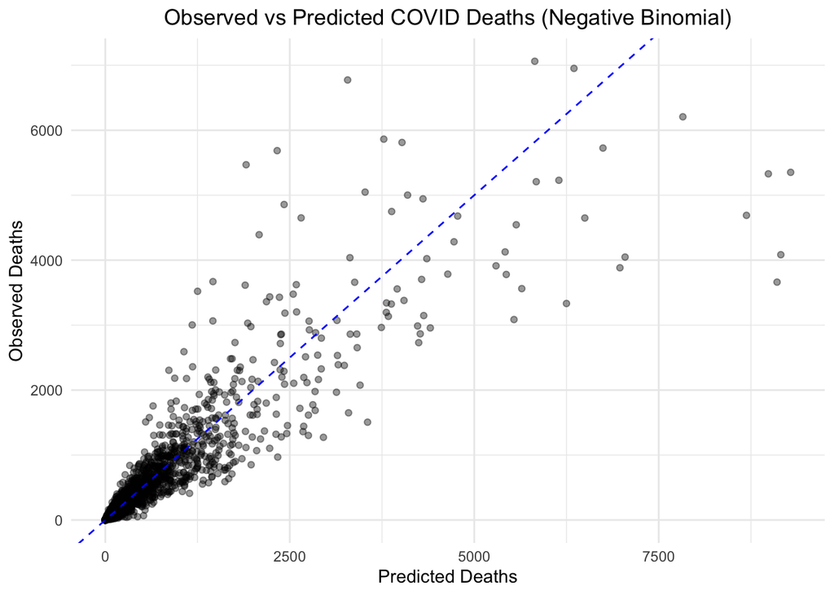

```r
# Copy of the modeling data with predictions added, so the data the models
# use (model_df) stays unchanged
pred_df <- model_df %>%
  mutate(
    pred_nb = predict(neg_binomial_regression, type = "response") # predicted death counts
  )

ggplot(pred_df, aes(x = pred_nb, y = COVID.19.Deaths)) +
  geom_point(alpha = 0.4) +
  geom_abline(slope = 1, intercept = 0, linetype = "dashed", color = "blue") +
  labs(
    title = "Observed vs Predicted COVID Deaths (Negative Binomial)",
    x = "Predicted Deaths",
    y = "Observed Deaths"
  ) +
  theme_minimal() +
  theme(plot.title = element_text(hjust = 0.5))
```

- Observed and predicted deaths agree most closely in the lower range of the data. The increasing spread at higher predicted values is consistent with the negative binomial variance function, in which variability grows with the mean.
- The largest predicted counts are systematically overestimated, and several cells exceed their predictions substantially. This suggests state-level variation that region alone does not capture, which motivates the mixed model with state random effects.

### Residual Diagnostics (DHARMa):

##### Does the negative binomial model fit the data adequately?

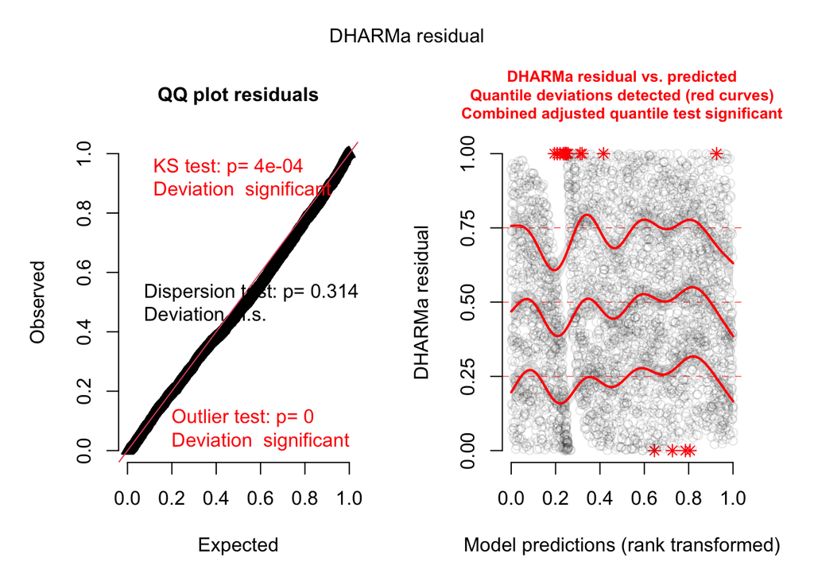

```r
# Simulate 1,000 datasets from the fitted model. For each observation, the scaled
# residual is the percentile of the observed count among its simulated values.
# If the model is correct, these residuals are uniformly distributed between 0 and 1.
nb_sim <- simulateResiduals(neg_binomial_regression, n = 1000, seed = 204) # seed to keep it reproducible

# Left: Q-Q plot against the uniform distribution, with tests for uniformity (KS), dispersion, and outliers.
# Right: scaled residuals vs. predicted values; lines should be flat at 0.25, 0.5, 0.75.
plot(nb_sim)
```

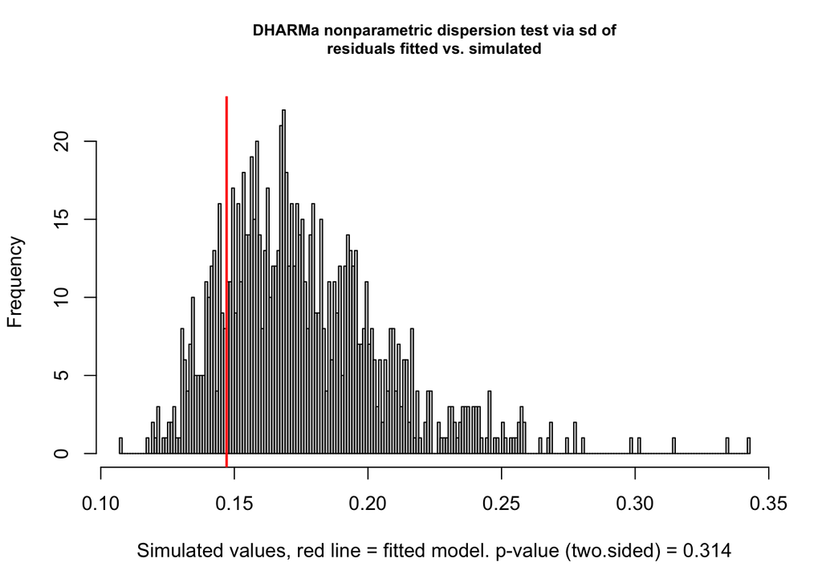

```
    DHARMa nonparametric dispersion test via sd of residuals fitted vs.
    simulated

data:  simulationOutput
dispersion = 0.8371, p-value = 0.314
alternative hypothesis: two.sided
```

```r
# Is there still more (or less) variation than the negative binomial model expects?
testDispersion(nb_sim)
```

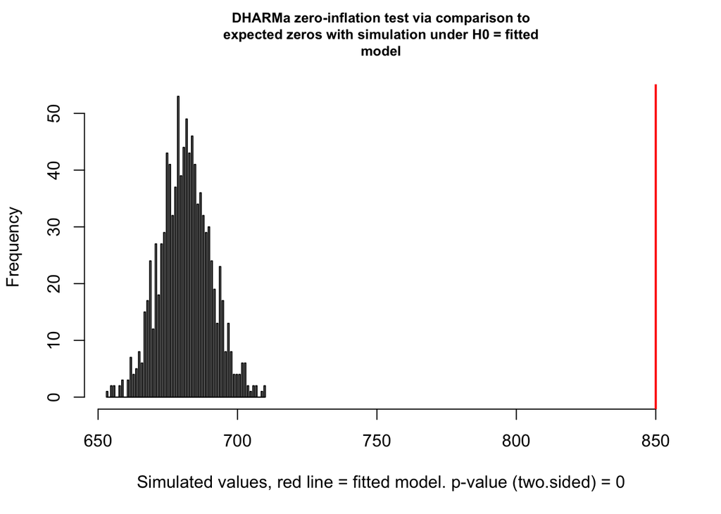

```
    DHARMa zero-inflation test via comparison to expected zeros with
    simulation under H0 = fitted model

data:  simulationOutput
ratioObsSim = 1.2472, p-value < 2.2e-16
alternative hypothesis: two.sided
```

```r
# Are there more zero-death cells than the model predicts?
testZeroInflation(nb_sim)
```

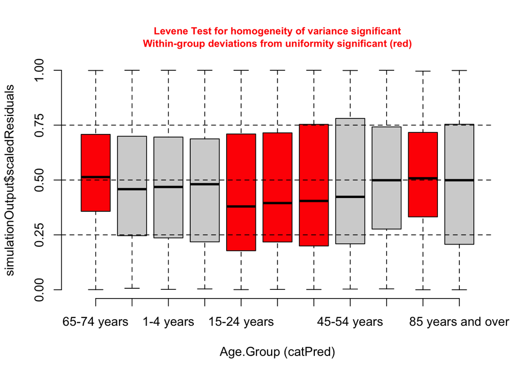

```r
# Residuals by age group: each box should be centered around 0.5 if the model
# fits equally well across ages
plotResiduals(nb_sim, form = model_df$Age.Group)
```

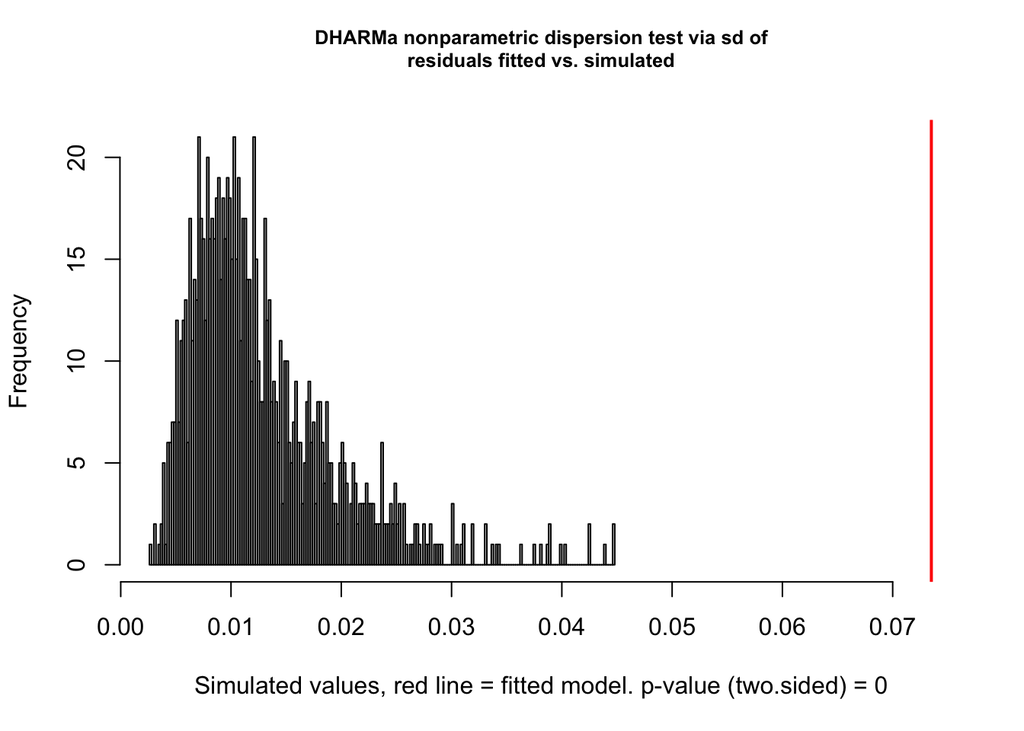

```
    DHARMa nonparametric dispersion test via sd of residuals fitted vs.
    simulated

data:  simulationOutput
dispersion = 5.7547, p-value < 2.2e-16
alternative hypothesis: two.sided
```

```r
# Group residuals by state: if some states are consistently above or below their
# predictions, the state-level residuals will be overdispersed. That would mean
# there is state-level variation the model does not account for.
nb_sim_state <- recalculateResiduals(
  nb_sim,
  group = model_df$State
)
testDispersion(nb_sim_state)
```

#### DHARMa Interpretation:

- Simulation-based residuals (DHARMa) indicate adequate overall fit. The Q-Q plot closely follows the expected uniform distribution, and the dispersion test shows no remaining overdispersion (ratio = 0.84, p = 0.31). The significant KS test reflects small deviations detectable at this sample size.
- Residuals plotted against predicted values are close to uniform across most of the prediction range. The clear exception is cells with small predicted counts, where observed values are concentrated at zero and above 10. This pattern is consistent with CDC suppression of counts from 1 to 9, which removes the intermediate values from exactly these cells. A few cells with large predicted counts fall below all simulated values, consistent with state-level variation not captured by region.
- The model underpredicts zero-death cells (850 observed vs. about 680 expected; ratio = 1.25). This likely reflects CDC suppression, which removes counts of 1–9 while keeping zeros, rather than true zero inflation. We address it through multiple imputation of suppressed counts rather than a zero-inflated model.
- Residuals vary by age group: deaths are overpredicted at ages 15–54, where suppression is heaviest, and older groups show less variability than the model assumes.
- Residuals aggregated by state are strongly overdispersed (ratio = 5.75, p < 0.001), indicating state-level variation that region does not capture. We address this with a mixed model including state random intercepts.

### Negative Binomial Mixed Model (State Random Intercepts):

##### Does accounting for state-level variation change the estimates?

```r
# Same negative binomial model, plus a random intercept for each state.
# nbinom2 = the same variance form as glm.nb: Var(Y) = mu + mu^2 / theta
nb_mixed <- glmmTMB(
  COVID.19.Deaths ~ Sex +
    region +
    factor(Year) +
    Age.Group +
    offset(log(person_years)) +
    (1 | State), # random intercept: each state gets its own baseline shift u_j
  family = nbinom2,
  data = model_df
)

summary(nb_mixed)
```

```
 Family: nbinom2  ( log )
Formula:
COVID.19.Deaths ~ Sex + region + factor(Year) + Age.Group + offset(log(person_years)) +
    (1 | State)
Data: model_df

      AIC       BIC    logLik -2*log(L)  df.resid
  28393.7   28516.1  -14176.9   28353.7      3332

Random effects:

Conditional model:
 Groups Name        Variance Std.Dev.
 State  (Intercept) 0.05358  0.2315
Number of obs: 3352, groups:  State, 51

Dispersion parameter for nbinom2 family (): 7.78

Conditional model:
                           Estimate Std. Error z value Pr(>|z|)
(Intercept)                -6.46854    0.07203  -89.80  < 2e-16 ***
SexMale                     0.43405    0.01500   28.93  < 2e-16 ***
regionnortheast            -0.21197    0.10507   -2.02  0.04365 *
regionsouth                 0.23069    0.08954    2.58  0.00999 **
regionwest                 -0.10322    0.09527   -1.08  0.27863
factor(Year)2021            0.49036    0.02058   23.82  < 2e-16 ***
factor(Year)2022           -0.28868    0.02075  -13.91  < 2e-16 ***
factor(Year)2023           -1.66522    0.02360  -70.57  < 2e-16 ***
Age.GroupUnder 1 year      -5.31828    0.15493  -34.33  < 2e-16 ***
Age.Group1-4 years         -7.67304    0.20883  -36.74  < 2e-16 ***
Age.Group5-14 years        -7.52275    0.13906  -54.10  < 2e-16 ***
Age.Group15-24 years       -4.64961    0.04713  -98.66  < 2e-16 ***
Age.Group25-34 years       -3.30470    0.03335  -99.08  < 2e-16 ***
Age.Group35-44 years       -2.42116    0.03027  -79.97  < 2e-16 ***
Age.Group45-54 years       -1.54978    0.02787  -55.62  < 2e-16 ***
Age.Group55-64 years       -0.77976    0.02667  -29.24  < 2e-16 ***
Age.Group75-84 years        0.98459    0.02611   37.71  < 2e-16 ***
Age.Group85 years and over  2.16310    0.02625   82.40  < 2e-16 ***
---
Signif. codes:  0 '***' 0.001 '**' 0.01 '*' 0.05 '.' 0.1 ' ' 1
```

```r
# Convergence checks (warnings are hidden in this document, so check explicitly)
nb_mixed$fit$convergence == 0 # TRUE = optimizer converged
```

```
[1] TRUE
```

```r
nb_mixed$sdr$pdHess # TRUE = standard errors are reliable
```

```
[1] TRUE
```

```r
# Between-state standard deviation (sigma) on the log-rate scale
sigma_state <- sqrt(VarCorr(nb_mixed)$cond$State[1])
```

```r
# How much do standard errors change once state-level correlation is modeled?
se_nb <- summary(neg_binomial_regression)$coefficients[, "Std. Error"]
se_mixed <- summary(nb_mixed)$coefficients$cond[, "Std. Error"]
key_terms <- c(
  "SexMale",
  "regionnortheast",
  "regionsouth",
  "regionwest",
  "factor(Year)2021",
  "factor(Year)2022",
  "factor(Year)2023"
)

kable(
  data.frame(
    Term = key_terms,
    SE_NB = se_nb[key_terms],
    SE_Mixed = se_mixed[key_terms],
    Ratio = se_mixed[key_terms] / se_nb[key_terms] # > 1 means the plain NB model was overconfident
  ),
  caption = "Standard Errors: Negative Binomial vs. Mixed Model",
  digits = 3,
  col.names = c("Term", "SE (NB)", "SE (Mixed)", "Ratio (Mixed / NB)"),
  row.names = FALSE,
  align = "l"
)
```

Standard Errors: Negative Binomial vs. Mixed Model

| Term | SE (NB) | SE (Mixed) | Ratio (Mixed / NB) |
| --- | --- | --- | --- |
| SexMale | 0.017 | 0.015 | 0.865 |
| regionnortheast | 0.028 | 0.105 | 3.768 |
| regionsouth | 0.023 | 0.090 | 3.908 |
| regionwest | 0.025 | 0.095 | 3.804 |
| factor(Year)2021 | 0.023 | 0.021 | 0.888 |
| factor(Year)2022 | 0.024 | 0.021 | 0.873 |
| factor(Year)2023 | 0.027 | 0.024 | 0.871 |

```r
# Model comparison: both are fit by maximum likelihood, so AICs are comparable
kable(
  AIC(neg_binomial_regression, nb_mixed),
  caption = "AIC: NB vs. Mixed Model",
  digits = 1
)
```

AIC: NB vs. Mixed Model

|  | df | AIC |
| --- | --- | --- |
| neg_binomial_regression | 19 | 28996.7 |
| nb_mixed | 20 | 28393.7 |

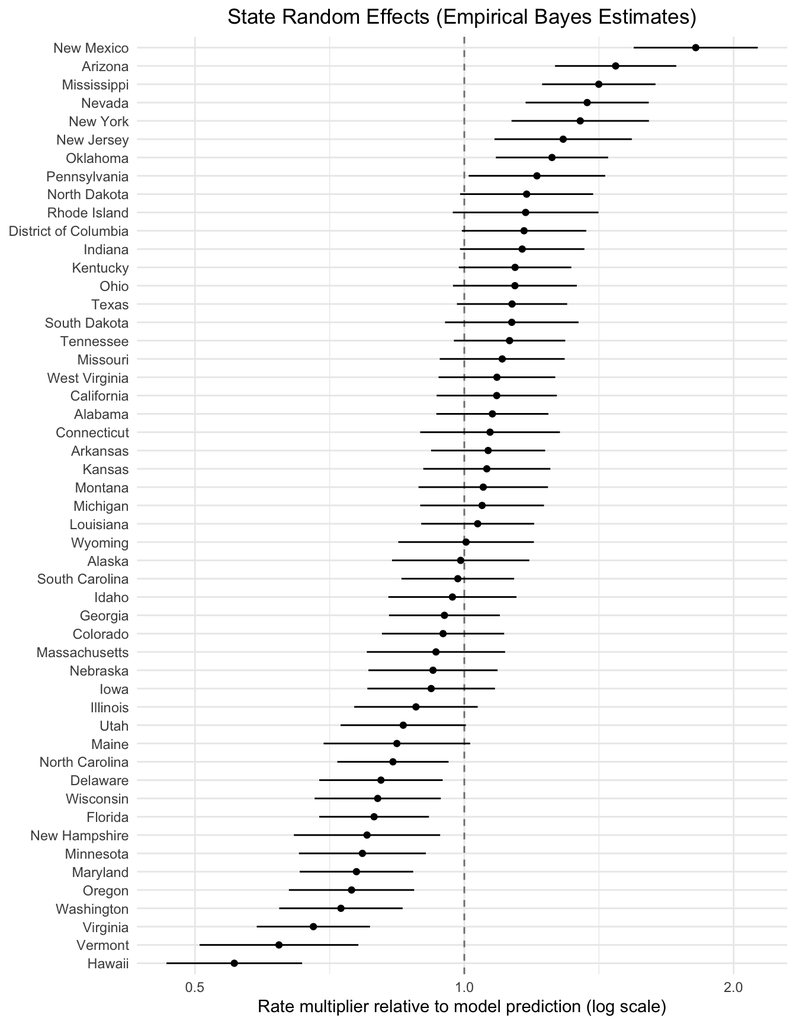

```r
# Caterpillar plot: each state's estimated random effect (empirical Bayes estimate),
# exponentiated to a rate multiplier, with 95% intervals
state_effects <- tidy(nb_mixed, effects = "ran_vals", conf.int = TRUE) %>%
  mutate(
    State = tools::toTitleCase(level),
    multiplier = exp(estimate), # e.g., 1.22 = 22% higher than predicted for its region
    low = exp(conf.low),
    high = exp(conf.high)
  )

ggplot(state_effects, aes(x = multiplier, y = reorder(State, multiplier))) +
  geom_vline(xintercept = 1, linetype = "dashed", color = "gray50") + # 1 = no difference from prediction
  geom_errorbar(aes(xmin = low, xmax = high), width = 0, orientation = "y") +
  geom_point() +
  scale_x_log10() +
  labs(
    title = "State Random Effects (Empirical Bayes Estimates)",
    x = "Rate multiplier relative to model prediction (log scale)",
    y = NULL
  ) +
  theme_minimal() +
  theme(plot.title = element_text(hjust = 0.5))
```

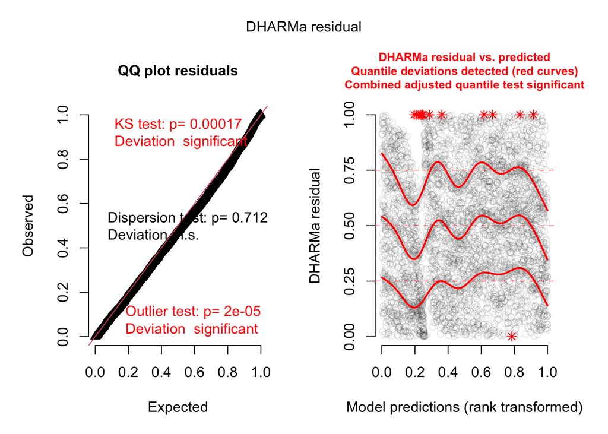

```r
# Rerun the DHARMa diagnostics on the mixed model; the state-grouped dispersion
# should now be close to 1 if the random effects captured the state-level variation
mixed_sim <- simulateResiduals(nb_mixed, n = 1000, seed = 204)
plot(mixed_sim)
```

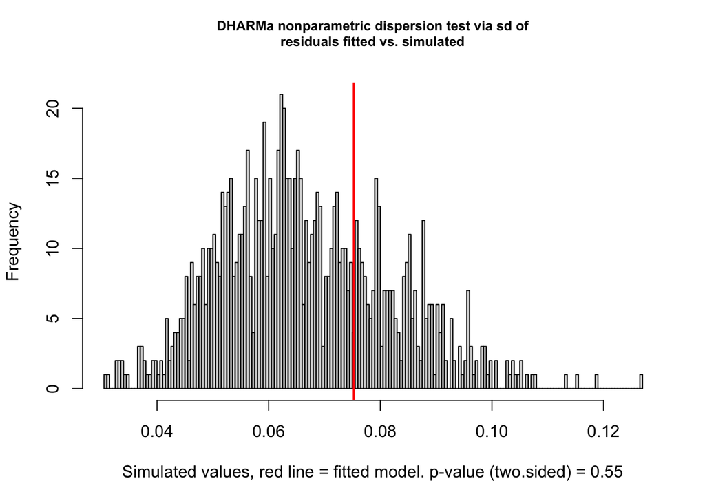

```
    DHARMa nonparametric dispersion test via sd of residuals fitted vs.
    simulated

data:  simulationOutput
dispersion = 1.1339, p-value = 0.55
alternative hypothesis: two.sided
```

```r
mixed_sim_state <- recalculateResiduals(
  mixed_sim,
  group = model_df$State
)
testDispersion(mixed_sim_state)
```

#### Interpretation:

- **State variation:** States differed substantially beyond what region, age, sex, and year explain (between-state SD = 0.23 on the log-rate scale). About 95% of states had mortality rates between 0.64 and 1.57 times their predicted rate.
- **Model fit:** Adding state random intercepts reduced AIC by 603 (28,996.7 to 28,393.7) for one additional parameter. The negative binomial dispersion parameter increased from 5.64 to 7.78, indicating that part of the overdispersion in the fixed-effects model reflected systematic state differences.
- **Standard errors:** Region standard errors increased about 3.8-fold because region varies only between states, so the fixed-effects model overstated the precision of regional comparisons. Sex and year standard errors decreased slightly (about 13%) because these comparisons are made within states.
- **Region:** With correct uncertainty, the South had higher mortality than the Midwest (RR = 1.26; 95% CI: 1.06–1.50), the Northeast had marginally lower mortality (RR = 0.81; 0.66–0.99), and the West did not differ (RR = 0.90; 0.75–1.09).
- **Other effects:** Estimates for sex (RR = 1.54; 1.50–1.59), year (2021 vs. 2020 RR = 1.63; 1.57–1.70), and age (85+ vs. 65–74 RR = 8.70; 8.26–9.16) were nearly unchanged from the fixed-effects model.
- **State effects (empirical Bayes):** The state estimates are shrunk toward the overall mean, with more shrinkage for states contributing less information (smaller populations, more suppressed cells). New Mexico, Arizona, and Mississippi had the highest mortality relative to prediction, and Hawaii, Vermont, and Virginia the lowest. States within the same region differed widely (e.g., New Mexico and Hawaii, both in the West), showing that region is too coarse to capture geographic variation.
- **Diagnostics:** Residuals grouped by state are no longer overdispersed (dispersion = 1.13, p = 0.55, compared with 5.75 before), confirming that the random intercepts capture the state-level variation. The remaining misfit among cells with small predicted counts reflects CDC suppression, addressed next through multiple imputation.

### Multiple Imputation of Suppressed Counts:

##### Do the results change when suppressed counts (1–9 deaths) are imputed rather than excluded?

```r
# 1. All cells with a known region and population, INCLUDING suppressed (NA) counts
# Same factor setup as the modeling data, so coefficient names match
full_df <- joined_df %>%
  mutate(
    region = factor(case_when(
      State %in% west ~ "west",
      State %in% midwest ~ "midwest",
      State %in% south ~ "south",
      State %in% northeast ~ "northeast"
    ))
  ) %>%
  filter(!is.na(region), !is.na(person_years)) %>% # keeps suppressed rows, drops territories
  mutate(
    Age.Group = relevel(
      factor(Age.Group, levels = age_groups_keep),
      ref = "65-74 years"
    ),
    Sex = factor(Sex, levels = c("Female", "Male")),
    suppressed = is.na(COVID.19.Deaths) # TRUE = suppressed (1-9 deaths)
  )

# Number of cells to impute
n_suppressed <- sum(full_df$suppressed)

# 2. Pieces of the fitted mixed model used to generate imputations
beta_hat <- fixef(nb_mixed)$cond # fixed-effect estimates
V_beta <- vcov(nb_mixed)$cond # their covariance matrix (estimation uncertainty)
theta_hat <- sigma(nb_mixed) # NB dispersion parameter (theta) for nbinom2
state_re <- ranef(nb_mixed)$cond$State # each state's random effect (empirical Bayes estimate)

# Dataframe of only the suppressed death count rows
suppressed_df <- full_df %>% filter(suppressed)

# Design matrix: one row per suppressed cell, one column per fixed-effect coefficient
X_suppressed <- model.matrix(
  ~ Sex + region + factor(Year) + Age.Group,
  data = suppressed_df
)[, names(beta_hat)]
u_suppressed <- state_re[suppressed_df$State, "(Intercept)"] # match each cell to its state's random effect
```

```r
# 3. Impute m = 40 times, refit the mixed model each time
m <- 40
set.seed(204)
mi_fits <- vector("list", m) # Empty list with 20 elements

# Imputation step
for (i in 1:m) {
  # Draw a plausible coefficient vector from its sampling distribution
  beta_star <- mvrnorm(1, mu = beta_hat, Sigma = V_beta)

  # Predicted mean deaths for each suppressed cell under the drawn coefficients
  mu_suppressed <- as.vector(exp(
    X_suppressed %*% beta_star + u_suppressed + log(suppressed_df$person_years)
  ))

  # Draw each suppressed count from the NB distribution restricted to 1-9:
  # probabilities of 1, 2, ..., 9 under the model, rescaled to sum to 1 (sample() does the rescaling)
  imputed <- sapply(mu_suppressed, function(mu_i) {
    sample(1:9, size = 1, prob = dnbinom(1:9, size = theta_hat, mu = mu_i))
  })

  # Add the imputed values into the full dataframe (a copy of it)
  completed <- full_df
  completed$COVID.19.Deaths[completed$suppressed] <- imputed # same row order as suppressed_df

  # Refit the statistical model using the completed data
  mi_fits[[i]] <- glmmTMB(
    COVID.19.Deaths ~ Sex +
      region +
      factor(Year) +
      Age.Group +
      offset(log(person_years)) +
      (1 | State),
    family = nbinom2,
    data = completed
  )
}
```

```r
# Show only the cells that were suppressed, with their imputed values.
# This table only shows the imputed values after the 40th imputation run
completed %>%
  filter(suppressed) %>% # keep only the previously suppressed cells
  dplyr::select(State, Year, Sex, Age.Group, person_years, COVID.19.Deaths) %>%
  head(15) %>%
  kable(
    caption = paste0("Example Imputed Values (Imputation ", m, " of ", m, ")"),
    digits = 1,
    col.names = c(
      "State",
      "Year",
      "Sex",
      "Age Group",
      "Person-Years",
      "Imputed Deaths"
    ),
    align = "l"
  )
```

Example Imputed Values (Imputation 40 of 40)

| State | Year | Sex | Age Group | Person-Years | Imputed Deaths |
| --- | --- | --- | --- | --- | --- |
| alabama | 2020 | Female | 15-24 years | 348282.7 | 7 |
| alabama | 2020 | Female | Under 1 year | 27478.3 | 1 |
| alabama | 2020 | Male | 15-24 years | 340953.7 | 6 |
| alabama | 2020 | Male | Under 1 year | 28916.3 | 1 |
| alabama | 2021 | Female | 1-4 years | 113649.2 | 1 |
| alabama | 2021 | Female | 5-14 years | 306182.3 | 2 |
| alabama | 2021 | Male | Under 1 year | 28892.2 | 1 |
| alabama | 2022 | Female | 1-4 years | 114070.9 | 1 |
| alabama | 2022 | Female | 15-24 years | 354160.4 | 3 |
| alabama | 2022 | Female | 5-14 years | 305598.7 | 1 |
| alabama | 2022 | Male | 1-4 years | 118697.7 | 1 |
| alabama | 2022 | Male | 15-24 years | 348464.3 | 8 |
| alabama | 2022 | Male | Under 1 year | 29655.7 | 1 |
| alabama | 2023 | Female | 25-34 years | 238927.4 | 2 |
| alabama | 2023 | Female | 35-44 years | 235173.9 | 7 |

```r
# 4. Pool the 40 fits with Rubin's rules
est <- sapply(mi_fits, function(f) fixef(f)$cond) # coefficients: one column per imputation. the 40 different estimates of each regression coefficient
wvar <- sapply(mi_fits, function(f) diag(vcov(f)$cond)) # squared SEs: one column per imputation. estimated variance of each coefficient from each fitted model

Q_bar <- rowMeans(est) # pooled estimate
U_bar <- rowMeans(wvar) # within-imputation variance
B <- apply(est, 1, var) # between-imputation variance
T_var <- U_bar + (1 + 1 / m) * B # total variance
se_pooled <- sqrt(T_var)

# Rubin's degrees of freedom and fraction of missing information
df_rubin <- (m - 1) * (1 + U_bar / ((1 + 1 / m) * B))^2
fmi <- (1 + 1 / m) * B / T_var
t_crit <- qt(0.975, df_rubin)

# Complete-case results (the mixed model fit without suppressed cells), for comparison
cc_est <- fixef(nb_mixed)$cond
cc_se <- sqrt(diag(vcov(nb_mixed)$cond))

# Formats numbers to 3 significant digits without scientific notation,
# so tiny rate ratios show as 0.000421 instead of 0.000
fmt3 <- function(x) formatC(x, format = "fg", digits = 3)

mi_compare <- data.frame(
  Term = names(Q_bar),
  RR_CC = fmt3(exp(cc_est)),
  CI_CC = paste0(
    fmt3(exp(cc_est - 1.96 * cc_se)),
    "–",
    fmt3(exp(cc_est + 1.96 * cc_se))
  ),
  RR_MI = fmt3(exp(Q_bar)),
  CI_MI = paste0(
    fmt3(exp(Q_bar - t_crit * se_pooled)),
    "–",
    fmt3(exp(Q_bar + t_crit * se_pooled))
  ),
  FMI = round(fmi, 3)
) %>%
  filter(Term != "(Intercept)")

kable(
  mi_compare,
  caption = paste0(
    "Mixed Model Rate Ratios: Complete Cases vs. Multiple Imputation (",
    n_suppressed,
    " suppressed cells imputed, m = ",
    m,
    ")"
  ),
  col.names = c(
    "Term",
    "RR (complete cases)",
    "95% CI",
    "RR (imputed)",
    "95% CI",
    "Fraction missing info"
  ),
  row.names = FALSE,
  align = "l"
)
```

Mixed Model Rate Ratios: Complete Cases vs. Multiple Imputation (1136 suppressed cells imputed, m = 40)

| Term | RR (complete cases) | 95% CI | RR (imputed) | 95% CI | Fraction missing info |
| --- | --- | --- | --- | --- | --- |
| SexMale | 1.54 | 1.5–1.59 | 1.53 | 1.49–1.58 | 0.046 |
| regionnortheast | 0.809 | 0.658–0.994 | 0.787 | 0.639–0.968 | 0.005 |
| regionsouth | 1.26 | 1.06– 1.5 | 1.26 | 1.05– 1.5 | 0.004 |
| regionwest | 0.902 | 0.748–1.09 | 0.903 | 0.748–1.09 | 0.005 |
| factor(Year)2021 | 1.63 | 1.57– 1.7 | 1.68 | 1.62–1.75 | 0.026 |
| factor(Year)2022 | 0.749 | 0.719–0.78 | 0.787 | 0.757–0.819 | 0.033 |
| factor(Year)2023 | 0.189 | 0.181–0.198 | 0.19 | 0.182–0.199 | 0.081 |
| Age.GroupUnder 1 year | 0.0049 | 0.00362–0.00664 | 0.0118 | 0.0101–0.0139 | 0.309 |
| Age.Group1-4 years | 0.000465 | 0.000309–0.0007 | 0.00168 | 0.00141–0.002 | 0.123 |
| Age.Group5-14 years | 0.000541 | 0.000412–0.00071 | 0.00115 | 0.000971–0.00136 | 0.414 |
| Age.Group15-24 years | 0.00957 | 0.00872–0.0105 | 0.00894 | 0.00819–0.00976 | 0.340 |
| Age.Group25-34 years | 0.0367 | 0.0344–0.0392 | 0.0347 | 0.0326–0.037 | 0.105 |
| Age.Group35-44 years | 0.0888 | 0.0837–0.0942 | 0.0833 | 0.0786–0.0882 | 0.054 |
| Age.Group45-54 years | 0.212 | 0.201–0.224 | 0.206 | 0.195–0.217 | 0.023 |
| Age.Group55-64 years | 0.459 | 0.435–0.483 | 0.454 | 0.43–0.478 | 0.008 |
| Age.Group75-84 years | 2.68 | 2.54–2.82 | 2.7 | 2.57–2.85 | 0.002 |
| Age.Group85 years and over | 8.7 | 8.26–9.16 | 8.81 | 8.36–9.28 | 0.004 |

```r
# Term groups used in the interpretation text below
young_terms <- c(
  "Age.GroupUnder 1 year",
  "Age.Group1-4 years",
  "Age.Group5-14 years",
  "Age.Group15-24 years"
)
robust_terms <- c(
  "SexMale",
  "regionnortheast",
  "regionsouth",
  "regionwest",
  "Age.Group45-54 years",
  "Age.Group55-64 years",
  "Age.Group75-84 years",
  "Age.Group85 years and over"
)
```

#### Interpretation:

- We imputed 1136 suppressed cells (25% of all state-year-sex-age cells) from the mixed model’s predicted distribution restricted to 1–9 deaths, refit the model on each of 40 completed datasets, and pooled the results with Rubin’s rules.
- The imputation model was fit to the complete cases, with the state random effects and dispersion parameter held at their estimates. It assumes the model’s distribution, restricted to 1–9 deaths, reasonably describes the suppressed values.
- Estimates for sex, region, and ages 45 and older were essentially unchanged (fraction of missing information at most 4.6%), so these conclusions are robust to suppression.
- Year estimates shifted slightly (2021 vs. 2020 RR: 1.63 with complete cases vs. 1.68 with imputation), but the pattern of a 2021 peak and a steep decline by 2023 was unchanged.
- Suppression meaningfully affected the youngest age groups (fraction of missing information 12–41% for ages under 25). Complete-case estimates were too low for children under 15, whose remaining cells were mostly zeros, and slightly too high for young and middle-aged adults, whose remaining cells were mostly counts of 10 or more. The direction of suppression bias therefore depends on which values survive suppression in each group.

### Rate ratios with confidence intervals and a forest plot:

#### How do the final rate ratios compare with and without imputation?

```r
# Readable labels for each coefficient (reference groups in parentheses)
term_labels <- c(
  "SexMale" = "Male (vs. female)",
  "regionnortheast" = "Northeast (vs. Midwest)",
  "regionsouth" = "South (vs. Midwest)",
  "regionwest" = "West (vs. Midwest)",
  "factor(Year)2021" = "2021 (vs. 2020)",
  "factor(Year)2022" = "2022 (vs. 2020)",
  "factor(Year)2023" = "2023 (vs. 2020)",
  "Age.GroupUnder 1 year" = "Under 1",
  "Age.Group1-4 years" = "1–4",
  "Age.Group5-14 years" = "5–14",
  "Age.Group15-24 years" = "15–24",
  "Age.Group25-34 years" = "25–34",
  "Age.Group35-44 years" = "35–44",
  "Age.Group45-54 years" = "45–54",
  "Age.Group55-64 years" = "55–64",
  "Age.Group75-84 years" = "75–84",
  "Age.Group85 years and over" = "85+"
)

# One row per term per method, on the log scale first, then exponentiated
forest_df <- bind_rows(
  data.frame(
    term = names(cc_est),
    estimate = cc_est,
    low = cc_est - 1.96 * cc_se,
    high = cc_est + 1.96 * cc_se, # Wald 95% CI
    method = "Complete cases"
  ),
  data.frame(
    term = names(Q_bar),
    estimate = Q_bar,
    low = Q_bar - t_crit * se_pooled,
    high = Q_bar + t_crit * se_pooled, # Rubin's rules 95% CI
    method = "Multiple imputation"
  )
) %>%
  filter(term != "(Intercept)") %>%
  mutate(
    across(c(estimate, low, high), exp), # log rate ratios -> rate ratios
    label = term_labels[term],
    panel = if_else(
      startsWith(term, "Age.Group"),
      "Age group (vs. 65–74)",
      "Sex, region, and year"
    )
  )

rownames(forest_df) <- NULL

kable(
  forest_df %>%
    arrange(match(label, term_labels), method) %>% # order rows as listed in term_labels
    dplyr::select(label, method, estimate, low, high) %>%
    mutate(across(
      c(estimate, low, high),
      ~ formatC(.x, format = "fg", digits = 3)
    )), # 3 significant digits, no scientific notation
  col.names = c(
    "Comparison",
    "Method",
    "Rate Ratio",
    "95% CI Lower",
    "95% CI Upper"
  ),
  align = "l",
  caption = "Rate Ratios and 95% Confidence Intervals: Complete Cases vs. Multiple Imputation"
)
```

Rate Ratios and 95% Confidence Intervals: Complete Cases vs. Multiple Imputation

| Comparison | Method | Rate Ratio | 95% CI Lower | 95% CI Upper |
| --- | --- | --- | --- | --- |
| Male (vs. female) | Complete cases | 1.54 | 1.5 | 1.59 |
| Male (vs. female) | Multiple imputation | 1.53 | 1.49 | 1.58 |
| Northeast (vs. Midwest) | Complete cases | 0.809 | 0.658 | 0.994 |
| Northeast (vs. Midwest) | Multiple imputation | 0.787 | 0.639 | 0.968 |
| South (vs. Midwest) | Complete cases | 1.26 | 1.06 | 1.5 |
| South (vs. Midwest) | Multiple imputation | 1.26 | 1.05 | 1.5 |
| West (vs. Midwest) | Complete cases | 0.902 | 0.748 | 1.09 |
| West (vs. Midwest) | Multiple imputation | 0.903 | 0.748 | 1.09 |
| 2021 (vs. 2020) | Complete cases | 1.63 | 1.57 | 1.7 |
| 2021 (vs. 2020) | Multiple imputation | 1.68 | 1.62 | 1.75 |
| 2022 (vs. 2020) | Complete cases | 0.749 | 0.719 | 0.78 |
| 2022 (vs. 2020) | Multiple imputation | 0.787 | 0.757 | 0.819 |
| 2023 (vs. 2020) | Complete cases | 0.189 | 0.181 | 0.198 |
| 2023 (vs. 2020) | Multiple imputation | 0.19 | 0.182 | 0.199 |
| Under 1 | Complete cases | 0.0049 | 0.00362 | 0.00664 |
| Under 1 | Multiple imputation | 0.0118 | 0.0101 | 0.0139 |
| 1–4 | Complete cases | 0.000465 | 0.000309 | 0.0007 |
| 1–4 | Multiple imputation | 0.00168 | 0.00141 | 0.002 |
| 5–14 | Complete cases | 0.000541 | 0.000412 | 0.00071 |
| 5–14 | Multiple imputation | 0.00115 | 0.000971 | 0.00136 |
| 15–24 | Complete cases | 0.00957 | 0.00872 | 0.0105 |
| 15–24 | Multiple imputation | 0.00894 | 0.00819 | 0.00976 |
| 25–34 | Complete cases | 0.0367 | 0.0344 | 0.0392 |
| 25–34 | Multiple imputation | 0.0347 | 0.0326 | 0.037 |
| 35–44 | Complete cases | 0.0888 | 0.0837 | 0.0942 |
| 35–44 | Multiple imputation | 0.0833 | 0.0786 | 0.0882 |
| 45–54 | Complete cases | 0.212 | 0.201 | 0.224 |
| 45–54 | Multiple imputation | 0.206 | 0.195 | 0.217 |
| 55–64 | Complete cases | 0.459 | 0.435 | 0.483 |
| 55–64 | Multiple imputation | 0.454 | 0.43 | 0.478 |
| 75–84 | Complete cases | 2.68 | 2.54 | 2.82 |
| 75–84 | Multiple imputation | 2.7 | 2.57 | 2.85 |
| 85+ | Complete cases | 8.7 | 8.26 | 9.16 |
| 85+ | Multiple imputation | 8.81 | 8.36 | 9.28 |

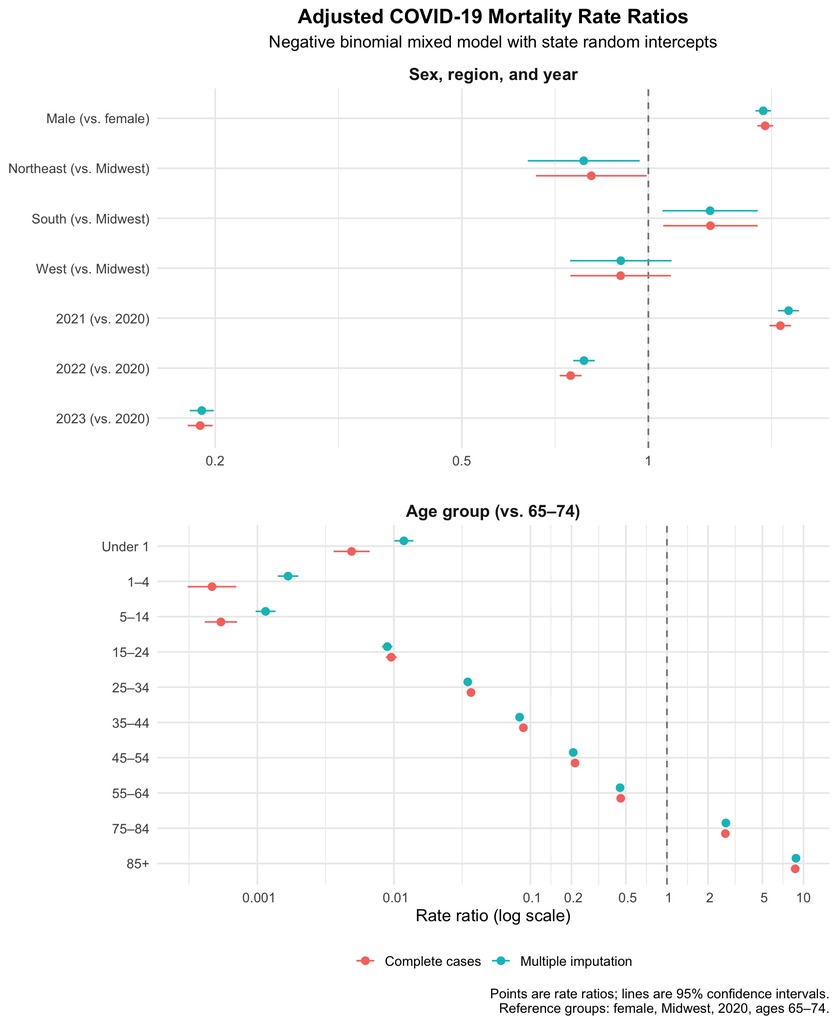

```r
forest_df <- forest_df %>%
  mutate(
    label = factor(label, levels = rev(unname(term_labels))), # top-to-bottom order
    panel = factor(
      panel,
      levels = c(
        "Sex, region, and year", # this panel first
        "Age group (vs. 65–74)"
      )
    )
  )

ggplot(forest_df, aes(x = estimate, y = label, color = method)) +
  geom_vline(xintercept = 1, linetype = "dashed", color = "gray50") +
  geom_pointrange(
    aes(xmin = low, xmax = high),
    position = position_dodge(width = 0.6, orientation = "y"),
    orientation = "y",
    size = 0.4
  ) +
  scale_x_log10(
    breaks = c(0.001, 0.01, 0.1, 0.2, 0.5, 1, 2, 5, 10), # each panel shows the ones in its range
    labels = function(x) format(x, scientific = FALSE, drop0trailing = TRUE) # 0.001, not 1e-03
  ) +
  facet_wrap(~panel, ncol = 1, scales = "free") +
  labs(
    title = "Adjusted COVID-19 Mortality Rate Ratios",
    subtitle = "Negative binomial mixed model with state random intercepts",
    x = "Rate ratio (log scale)",
    y = NULL,
    color = NULL,
    caption = "Points are rate ratios; lines are 95% confidence intervals.\nReference groups: female, Midwest, 2020, ages 65–74."
  ) +
  theme_minimal(base_size = 13) + # larger text throughout
  theme(
    legend.position = "bottom",
    plot.title = element_text(hjust = 0.5, face = "bold"),
    plot.subtitle = element_text(hjust = 0.5),
    strip.text = element_text(size = 13, face = "bold"), # panel titles
    panel.spacing = unit(1.5, "lines") # more space between panels
  )
```

```r
# Formats the imputed rate ratio and 95% CI for one term, like "1.53 (95% CI: 1.49–1.58)"
rr_text <- function(term_name, digits = 2) {
  row <- forest_df %>%
    filter(term == term_name, method == "Multiple imputation")
  fmt <- paste0("%.", digits, "f (95%% CI: %.", digits, "f–%.", digits, "f)") # %% prints a literal %
  sprintf(fmt, row$estimate, row$low, row$high)
}
```

#### Interpretation:

- **Age** was by far the strongest predictor, with mortality rising steeply and steadily with age. Compared with ages 65–74, rates were 2.70 (95% CI: 2.57–2.85) times as high at ages 75–84 and 8.81 (95% CI: 8.36–9.28) times as high at 85+.
- **Sex:** Males had higher mortality than females of the same age, region, and year (RR = 1.53 (95% CI: 1.49–1.58)).
- **Region:** The South had higher mortality than the Midwest (RR = 1.26 (95% CI: 1.05–1.50)), the Northeast had lower mortality (RR = 0.79 (95% CI: 0.64–0.97)), and the West did not clearly differ (RR = 0.90 (95% CI: 0.75–1.09)). Region intervals are the widest because only 51 states inform them.
- **Year:** Mortality peaked in 2021 (RR = 1.68 (95% CI: 1.62–1.75) vs. 2020) and fell sharply by 2023 (RR = 0.19 (95% CI: 0.18–0.20); January–September, annualized).
- **Effect of imputation:** Complete-case and imputed estimates were nearly identical for sex, region, year, and ages 15 and older. For children under 15, the complete-case analysis underestimated mortality, and imputation raised those estimates. The imputed intervals for these groups are also narrower because imputation restored suppressed information.

### Age × Sex Interaction (Likelihood Ratio Test):

##### Does the effect of age on COVID-19 mortality rates differ by sex?

```r
# Same mixed model as nb_mixed, plus the age x sex interaction
mixed_interaction <- glmmTMB(
  COVID.19.Deaths ~ Sex *
    Age.Group +
    region +
    factor(Year) +
    offset(log(person_years)) +
    (1 | State),
  family = nbinom2,
  data = model_df
)

# Convergence checks (warnings are hidden in this document, so check explicitly)
mixed_interaction$fit$convergence == 0 # TRUE = optimizer converged
```

```
[1] TRUE
```

```r
mixed_interaction$sdr$pdHess # TRUE = standard errors are reliable
```

```
[1] TRUE
```

```r
anova(nb_mixed, mixed_interaction) # print the full comparison table
```

```
Data: model_df
Models:
nb_mixed: COVID.19.Deaths ~ Sex + region + factor(Year) + Age.Group + offset(log(person_years)) + , zi=~0, disp=~1
nb_mixed:     (1 | State), zi=~0, disp=~1
mixed_interaction: COVID.19.Deaths ~ Sex * Age.Group + region + factor(Year) + offset(log(person_years)) + , zi=~0, disp=~1
mixed_interaction:     (1 | State), zi=~0, disp=~1
                  Df   AIC   BIC logLik deviance  Chisq Chi Df Pr(>Chisq)
nb_mixed          20 28394 28516 -14177    28354
mixed_interaction 30 28386 28570 -14163    28326 27.383     10   0.002264 **
---
Signif. codes:  0 '***' 0.001 '**' 0.01 '*' 0.05 '.' 0.1 ' ' 1
```

```r
# Likelihood ratio test, computed directly:
# statistic = 2 x (log-likelihood with interaction - log-likelihood without it)
ll_without <- logLik(nb_mixed)
ll_with <- logLik(mixed_interaction)
lrt_stat <- as.numeric(2 * (ll_with - ll_without))
lrt_df <- attr(ll_with, "df") - attr(ll_without, "df") # number of added interaction terms
lrt_p <- pchisq(lrt_stat, df = lrt_df, lower.tail = FALSE) # p-value from the chi-square distribution

# Effect size: male-to-female rate ratio within each age group (from the interaction model).
# For the reference age group, the ratio is exp(SexMale); for other groups, add that group's interaction term.
b <- fixef(mixed_interaction)$cond # fixed-effect coefficients of the mixed model
mf_ratio <- sapply(
  levels(model_df$Age.Group),
  function(a) {
    term <- paste0("SexMale:Age.Group", a) # e.g., "SexMale:Age.Group85 years and over"
    exp(b["SexMale"] + ifelse(term %in% names(b), b[term], 0))
  }
)

kable(
  data.frame(Age.Group = names(mf_ratio), Ratio = mf_ratio),
  caption = "Male-to-Female Mortality Rate Ratio by Age Group (Mixed Model)",
  digits = 2,
  col.names = c("Age Group", "Male:Female Rate Ratio"),
  row.names = FALSE,
  align = "l"
)
```

Male-to-Female Mortality Rate Ratio by Age Group (Mixed Model)

| Age Group | Male:Female Rate Ratio |
| --- | --- |
| 65-74 years.SexMale | 1.60 |
| Under 1 year.SexMale | 3.35 |
| 1-4 years.SexMale | 0.98 |
| 5-14 years.SexMale | 0.90 |
| 15-24 years.SexMale | 1.42 |
| 25-34 years.SexMale | 1.50 |
| 35-44 years.SexMale | 1.57 |
| 45-54 years.SexMale | 1.66 |
| 55-64 years.SexMale | 1.59 |
| 75-84 years.SexMale | 1.58 |
| 85 years and over.SexMale | 1.37 |

#### Interpretation:

- Adding the age × sex interaction significantly improved model fit (likelihood ratio test: χ² = 27.4, df = 10, p 0.0023). The male-to-female mortality rate ratio therefore differs across age groups.
- The male:female rate ratio ranged from 0.9 to 3.35 across age groups (table above).

### Interaction plot:

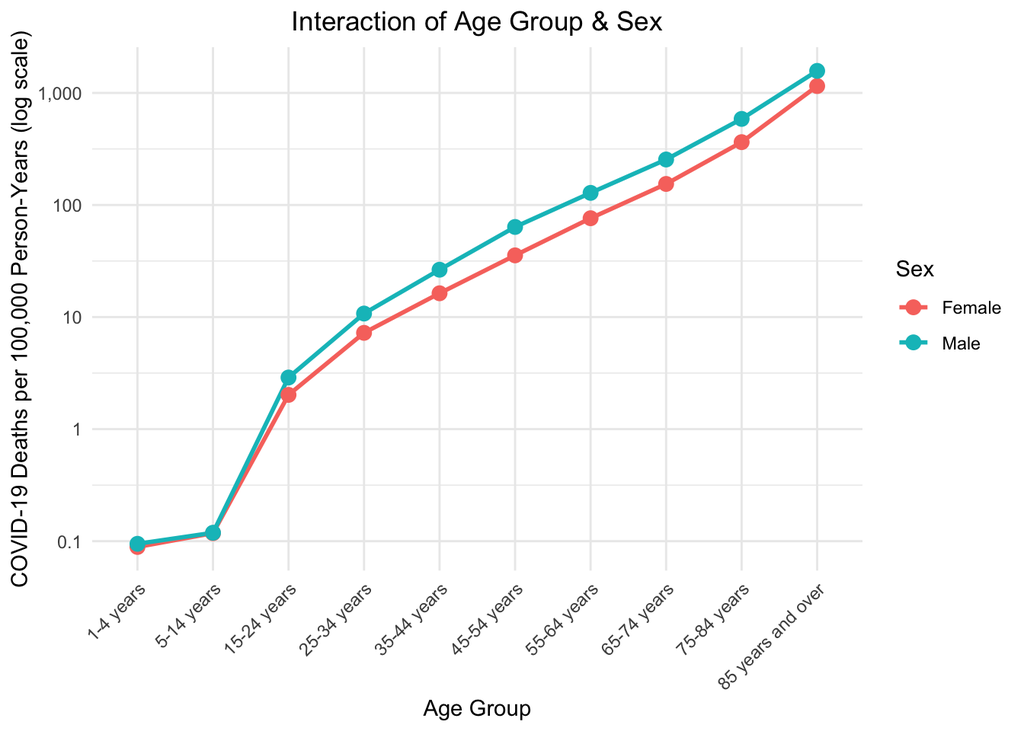

```r
interaction_subset <- model_df %>%
  filter(Age.Group != "Under 1 year") %>%
  mutate(Age.Group = factor(Age.Group, levels = age_groups_keep)) %>%
  group_by(Age.Group, Sex) %>%
  summarise(
    # pooled rate: total deaths / total person-years * 100,000, so large and small states are weighted correctly
    rate = sum(COVID.19.Deaths) / sum(person_years) * 100000,
    .groups = "drop"
  )

# Create the interaction plot (rates, not counts)
ggplot(
  interaction_subset,
  aes(x = Age.Group, y = rate, group = Sex, color = Sex)
) +
  geom_line(linewidth = 1) + # "size" is deprecated for lines in current ggplot2
  geom_point(size = 3) +
  scale_y_log10(
    labels = function(x) {
      format(x, scientific = FALSE, drop0trailing = TRUE, big.mark = ",")
    }
  ) + # log scale: parallel lines = no age x sex interaction
  labs(
    title = "Interaction of Age Group & Sex",
    x = "Age Group",
    y = "COVID-19 Deaths per 100,000 Person-Years (log scale)"
  ) +
  theme_minimal() +
  theme(
    axis.text.x = element_text(angle = 45, hjust = 1),
    plot.title = element_text(hjust = 0.5)
  )
```

#### Interpretation:

- Males had higher observed COVID-19 mortality rates than females from age 15 onward; below age 15, rates were nearly identical.
- On the log scale, the vertical gap between the lines reflects the male-to-female rate ratio. The relative male excess was largest in middle and older adulthood (about ages 45–74) and narrowed at ages 85 and older, although males remained at higher risk.
- This pattern agrees with the likelihood ratio test and the male:female rate ratio table above: the male excess varies by age rather than being constant.
- Rates for the youngest groups are based on complete cases only, where suppression is heaviest, so those points are approximate.

### Panel data plot:

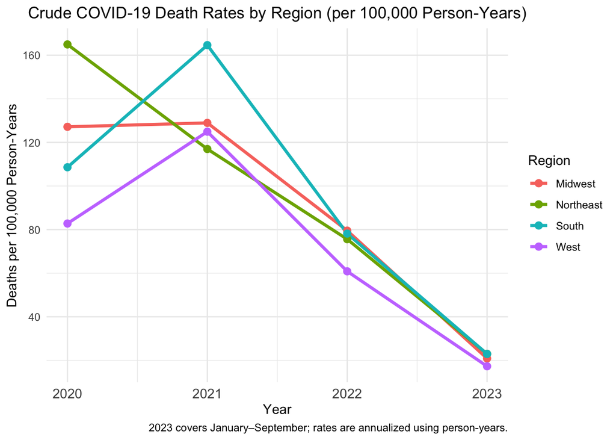

```r
region_year_panel <- map_df %>%
  mutate(
    region = case_when(
      State %in% west ~ "West",
      State %in% midwest ~ "Midwest",
      State %in% south ~ "South",
      State %in% northeast ~ "Northeast"
    )
  ) %>%
  filter(!is.na(region), !is.na(COVID.19.Deaths)) %>%
  group_by(region, Year) %>%
  summarise(
    deaths = sum(COVID.19.Deaths),
    person_years = sum(Population * year_fraction), # total state population, adjusted for partial 2023
    deaths_per_100000 = deaths / person_years * 100000,
    .groups = "drop"
  )

ggplot(
  region_year_panel,
  aes(x = Year, y = deaths_per_100000, color = region, group = region)
) +
  geom_line(linewidth = 1.2) +
  geom_point(size = 2.5) +
  labs(
    title = "Crude COVID-19 Death Rates by Region (per 100,000 Person-Years)",
    x = "Year",
    y = "Deaths per 100,000 Person-Years",
    caption = "2023 covers January–September; rates are annualized using person-years.",
    color = "Region"
  ) +
  scale_x_continuous(
    breaks = c(2020, 2021, 2022, 2023),
    labels = c("2020", "2021", "2022", "2023")
  ) +
  theme_minimal() +
  theme(
    plot.title = element_text(hjust = 0.5),
    axis.text.x = element_text(size = 11)
  )
```